```r
setwd('/media/jidde/Western Dig/analysis_backup_18_08_2021/levodopa project')
data <- readRDS("data_levodopa_29_01_21.rds")
```

Load Libraries

```r
library(ggplot2)
library(dplyr)
library(lme4)
library(car)
library(lmerTest)
library(visreg)
```

# Statistic analysis

Write Cohens d function

```r
lme.dscore<-function(mod,data,type){
  if (type=="lme4") {
    mod1<-lmerTest::lmer(mod,data=data)
    eff<-cbind(summary(mod1)$coefficients[,4],summary(mod1)$coefficients[,3])
  }

  if (type=="nlme") {
    eff=cbind(summary(mod)$tTable[,4],summary(mod)$fixDF$terms)
  }

  colnames(eff)<-c("t","df")
  eff<-as.data.frame(eff)
  eff$d<-(2*eff$t)/sqrt(eff$df)
  eff<-eff[-1,]
  return(eff)
}
```

# Models for VAI

Model with Gender as fixed effect & random intercepts for subjects

```r
m1 <- lmer(VAI ~ Gender + (1|participant.id), data = data)
summary(m1)
```

```
## Linear mixed model fit by REML. t-tests use Satterthwaite's method [
## lmerModLmerTest]
## Formula: VAI ~ Gender + (1 | participant.id)
##    Data: data
##
## REML criterion at convergence: -1082
##
## Scaled residuals:
##     Min      1Q  Median      3Q     Max
## -4.4469 -0.4681  0.0772  0.5028  2.9327
##
## Random effects:
##  Groups         Name        Variance Std.Dev.
##  participant.id (Intercept) 0.004579 0.06767
##  Residual                   0.001927 0.04390
## Number of obs: 339, groups:  participant.id, 17
##
## Fixed effects:
##             Estimate Std. Error       df t value Pr(>|t|)
## (Intercept)  1.01728    0.02418 14.99950  42.080  < 2e-16 ***
## Gendermale  -0.11560    0.03323 15.00120  -3.479  0.00336 **
## ---
## Signif. codes:  0 '***' 0.001 '**' 0.01 '*' 0.05 '.' 0.1 ' ' 1
##
## Correlation of Fixed Effects:
##            (Intr)
## Gendermale -0.728
```

Model with group and Gender as fixed & random intercepts for subjects

```r
summary(m2 <- lmer(VAI ~ group + Gender + (1|participant.id), data = data))
```

```
## Linear mixed model fit by REML. t-tests use Satterthwaite's method [
## lmerModLmerTest]
## Formula: VAI ~ group + Gender + (1 | participant.id)
##    Data: data
##
## REML criterion at convergence: -1078.4
##
## Scaled residuals:
##     Min      1Q  Median      3Q     Max
## -4.4424 -0.4640  0.0753  0.4994  2.9308
##
## Random effects:
##  Groups         Name        Variance Std.Dev.
##  participant.id (Intercept) 0.004667 0.06832
##  Residual                   0.001927 0.04390
## Number of obs: 339, groups:  participant.id, 17
##
## Fixed effects:
##             Estimate Std. Error       df t value Pr(>|t|)
## (Intercept)  1.00779    0.02683 13.99942  37.556 1.87e-15 ***
## groupPD      0.03795    0.04466 13.99955   0.850  0.40971
## Gendermale  -0.13985    0.04403 13.99988  -3.176  0.00673 **
## ---
## Signif. codes:  0 '***' 0.001 '**' 0.01 '*' 0.05 '.' 0.1 ' ' 1
##
## Correlation of Fixed Effects:
##            (Intr) gropPD
## groupPD    -0.416
## Gendermale -0.234 -0.648
```

```r
anova(m1, m2)
```

```
## refitting model(s) with ML (instead of REML)
```

```
## Data: data
## Models:
## m1: VAI ~ Gender + (1 | participant.id)
## m2: VAI ~ group + Gender + (1 | participant.id)
##    npar     AIC     BIC logLik deviance  Chisq Df Pr(>Chisq)
## m1    4 -1085.5 -1070.2 546.75  -1093.5
## m2    5 -1084.4 -1065.2 547.18  -1094.4 0.8551  1     0.3551
```

```r
anova(m2)
```

```
## Type III Analysis of Variance Table with Satterthwaite's method
##           Sum Sq   Mean Sq NumDF  DenDF F value   Pr(>F)
## group  0.0013917 0.0013917     1 13.999  0.7222 0.409708
## Gender 0.0194389 0.0194389     1 14.000 10.0880 0.006732 **
## ---
## Signif. codes:  0 '***' 0.001 '**' 0.01 '*' 0.05 '.' 0.1 ' ' 1
```

No improvement.

Add language as fixed effect

```r
summary(m3 <- lmer(VAI ~ group + Gender + lang + (1|participant.id), data = data))
```

```
## Linear mixed model fit by REML. t-tests use Satterthwaite's method [
## lmerModLmerTest]
## Formula: VAI ~ group + Gender + lang + (1 | participant.id)
##    Data: data
##
## REML criterion at convergence: -1073.6
##
## Scaled residuals:
##     Min      1Q  Median      3Q     Max
## -4.4434 -0.4661  0.0778  0.4997  2.9303
##
## Random effects:
##  Groups         Name        Variance Std.Dev.
##  participant.id (Intercept) 0.005029 0.07092
##  Residual                   0.001927 0.04390
## Number of obs: 339, groups:  participant.id, 17
##
## Fixed effects:
##               Estimate Std. Error       df t value Pr(>|t|)
## (Intercept)    1.00572    0.03385 13.00021  29.712 2.46e-13 ***
## groupPD        0.03849    0.04659 12.99958   0.826   0.4236
## Gendermale    -0.14084    0.04659 13.00047  -3.023   0.0098 **
## langSlovenian  0.00387    0.03601 13.00230   0.107   0.9160
## ---
## Signif. codes:  0 '***' 0.001 '**' 0.01 '*' 0.05 '.' 0.1 ' ' 1
##
## Correlation of Fixed Effects:
##             (Intr) gropPD Gndrml
## groupPD     -0.401
## Gendermale  -0.076 -0.653
## langSlovenn -0.569  0.108 -0.198
```

```r
anova(m2, m3)
```

```
## refitting model(s) with ML (instead of REML)
```

```
## Data: data
## Models:
## m2: VAI ~ group + Gender + (1 | participant.id)
## m3: VAI ~ group + Gender + lang + (1 | participant.id)
##    npar     AIC     BIC logLik deviance  Chisq Df Pr(>Chisq)
## m2    5 -1084.4 -1065.2 547.18  -1094.4
## m3    6 -1082.4 -1059.4 547.19  -1094.4 0.0151  1     0.9022
```

No improvement.

Add time of day as fixed effect.

```r
summary(m4 <- lmer(VAI ~ group + Gender + time + (1|participant.id), data = data))
```

```
## Linear mixed model fit by REML. t-tests use Satterthwaite's method [
## lmerModLmerTest]
## Formula: VAI ~ group + Gender + time + (1 | participant.id)
##    Data: data
##
## REML criterion at convergence: -1069.7
##
## Scaled residuals:
##     Min      1Q  Median      3Q     Max
## -4.4611 -0.4492  0.0915  0.5061  2.9022
##
## Random effects:
##  Groups         Name        Variance Std.Dev.
##  participant.id (Intercept) 0.004667 0.06831
##  Residual                   0.001932 0.04396
## Number of obs: 339, groups:  participant.id, 17
##
## Fixed effects:
##               Estimate Std. Error         df t value Pr(>|t|)
## (Intercept)   1.008878   0.026993  14.333895  37.376 1.08e-15 ***
## groupPD       0.037953   0.044654  13.999544   0.850  0.40966
## Gendermale   -0.139845   0.044030  13.999877  -3.176  0.00673 **
## timemorning  -0.001807   0.004877 321.004104  -0.370  0.71127
## ---
## Signif. codes:  0 '***' 0.001 '**' 0.01 '*' 0.05 '.' 0.1 ' ' 1
##
## Correlation of Fixed Effects:
##             (Intr) gropPD Gndrml
## groupPD     -0.414
## Gendermale  -0.233 -0.648
## timemorning -0.108  0.000  0.000
```

```r
anova(m2, m4)
```

```
## refitting model(s) with ML (instead of REML)
```

```
## Data: data
## Models:
## m2: VAI ~ group + Gender + (1 | participant.id)
## m4: VAI ~ group + Gender + time + (1 | participant.id)
##    npar     AIC     BIC logLik deviance  Chisq Df Pr(>Chisq)
## m2    5 -1084.4 -1065.2 547.18  -1094.4
## m4    6 -1082.5 -1059.5 547.25  -1094.5 0.1378  1     0.7104
```

No improvement.

Add day as fixed effect.

```r
summary(m5 <- lmer(VAI ~ group + Gender + day + (1|participant.id), data = data))
```

```
## Linear mixed model fit by REML. t-tests use Satterthwaite's method [
## lmerModLmerTest]
## Formula: VAI ~ group + Gender + day + (1 | participant.id)
##    Data: data
##
## REML criterion at convergence: -1053.7
##
## Scaled residuals:
##     Min      1Q  Median      3Q     Max
## -4.4636 -0.4597  0.0669  0.5219  2.8937
##
## Random effects:
##  Groups         Name        Variance Std.Dev.
##  participant.id (Intercept) 0.004667 0.06831
##  Residual                   0.001942 0.04407
## Number of obs: 339, groups:  participant.id, 17
##
## Fixed effects:
##               Estimate Std. Error         df t value Pr(>|t|)
## (Intercept)  1.009e+00  2.715e-02  1.467e+01  37.179 6.25e-16 ***
## groupPD      3.795e-02  4.466e-02  1.400e+01   0.850  0.40972
## Gendermale  -1.399e-01  4.403e-02  1.400e+01  -3.176  0.00673 **
## daysecond   -5.695e-04  6.760e-03  3.190e+02  -0.084  0.93291
## daythird    -1.904e-03  6.781e-03  3.190e+02  -0.281  0.77907
## dayfourth   -4.323e-03  6.760e-03  3.190e+02  -0.639  0.52297
## ---
## Signif. codes:  0 '***' 0.001 '**' 0.01 '*' 0.05 '.' 0.1 ' ' 1
##
## Correlation of Fixed Effects:
##            (Intr) gropPD Gndrml dyscnd dythrd
## groupPD    -0.411
## Gendermale -0.232 -0.648
## daysecond  -0.124  0.000  0.000
## daythird   -0.125  0.000  0.000  0.498
## dayfourth  -0.124  0.000  0.000  0.500  0.498
```

```r
anova(m2, m5)
```

```
## refitting model(s) with ML (instead of REML)
```

```
## Data: data
## Models:
## m2: VAI ~ group + Gender + (1 | participant.id)
## m5: VAI ~ group + Gender + day + (1 | participant.id)
##    npar     AIC     BIC logLik deviance  Chisq Df Pr(>Chisq)
## m2    5 -1084.4 -1065.2 547.18  -1094.4
## m5    8 -1078.8 -1048.2 547.43  -1094.8 0.4895  3     0.9212
```

```r
anova(m5)
```

```
## Type III Analysis of Variance Table with Satterthwaite's method
##           Sum Sq   Mean Sq NumDF DenDF F value   Pr(>F)
## group  0.0014026 0.0014026     1    14  0.7222 0.409717
## Gender 0.0195919 0.0195919     1    14 10.0879 0.006732 **
## day    0.0009425 0.0003142     3   319  0.1618 0.922022
## ---
## Signif. codes:  0 '***' 0.001 '**' 0.01 '*' 0.05 '.' 0.1 ' ' 1
```

No improvement.

Add age as fixed effect.

```r
summary(m6 <- lmer(VAI ~ group + Gender + age + (1|participant.id), data = data))
```

```
## Linear mixed model fit by REML. t-tests use Satterthwaite's method [
## lmerModLmerTest]
## Formula: VAI ~ group + Gender + age + (1 | participant.id)
##    Data: data
##
## REML criterion at convergence: -1067.9
##
## Scaled residuals:
##     Min      1Q  Median      3Q     Max
## -4.4425 -0.4672  0.0779  0.4988  2.9286
##
## Random effects:
##  Groups         Name        Variance Std.Dev.
##  participant.id (Intercept) 0.004992 0.07066
##  Residual                   0.001927 0.04390
## Number of obs: 339, groups:  participant.id, 17
##
## Fixed effects:
##               Estimate Std. Error         df t value Pr(>|t|)
## (Intercept)  1.0491044  0.1297564 13.0066276   8.085 1.98e-06 ***
## groupPD      0.0387281  0.0462146 12.9998099   0.838  0.41717
## Gendermale  -0.1384889  0.0456989 12.9999210  -3.030  0.00966 **
## age         -0.0006694  0.0020541 13.0067791  -0.326  0.74969
## ---
## Signif. codes:  0 '***' 0.001 '**' 0.01 '*' 0.05 '.' 0.1 ' ' 1
##
## Correlation of Fixed Effects:
##            (Intr) gropPD Gndrml
## groupPD    -0.038
## Gendermale  0.039 -0.640
## age        -0.977 -0.052 -0.091
```

```r
anova(m2, m6)
```

```
## refitting model(s) with ML (instead of REML)
```

```
## Data: data
## Models:
## m2: VAI ~ group + Gender + (1 | participant.id)
## m6: VAI ~ group + Gender + age + (1 | participant.id)
##    npar     AIC     BIC logLik deviance  Chisq Df Pr(>Chisq)
## m2    5 -1084.4 -1065.2 547.18  -1094.4
## m6    6 -1082.5 -1059.5 547.25  -1094.5 0.1383  1       0.71
```

No improvement.

## Interactions

Interaction between group and Gender.

```r
summary(m7 <- lmer(VAI ~ group*Gender + (1|participant.id), data = data))
```

```
## Linear mixed model fit by REML. t-tests use Satterthwaite's method [
## lmerModLmerTest]
## Formula: VAI ~ group * Gender + (1 | participant.id)
##    Data: data
##
## REML criterion at convergence: -1078.5
##
## Scaled residuals:
##     Min      1Q  Median      3Q     Max
## -4.4343 -0.4568  0.0823  0.5069  2.9365
##
## Random effects:
##  Groups         Name        Variance Std.Dev.
##  participant.id (Intercept) 0.003984 0.06312
##  Residual                   0.001927 0.04390
## Number of obs: 339, groups:  participant.id, 17
##
## Fixed effects:
##                    Estimate Std. Error       df t value Pr(>|t|)
## (Intercept)         0.99325    0.02608 12.99958  38.086 1.01e-14 ***
## groupPD             0.09612    0.05216 12.99958   1.843   0.0883 .
## Gendermale         -0.03805    0.06900 12.99958  -0.551   0.5907
## groupPD:Gendermale -0.15634    0.08551 12.99987  -1.828   0.0905 .
## ---
## Signif. codes:  0 '***' 0.001 '**' 0.01 '*' 0.05 '.' 0.1 ' ' 1
##
## Correlation of Fixed Effects:
##             (Intr) gropPD Gndrml
## groupPD     -0.500
## Gendermale  -0.378  0.189
## grpPD:Gndrm  0.305 -0.610 -0.807
```

```r
anova(m7, m2)
```

```
## refitting model(s) with ML (instead of REML)
```

```
## Data: data
## Models:
## m2: VAI ~ group + Gender + (1 | participant.id)
## m7: VAI ~ group * Gender + (1 | participant.id)
##    npar     AIC     BIC logLik deviance  Chisq Df Pr(>Chisq)
## m2    5 -1084.4 -1065.2 547.18  -1094.4
## m7    6 -1086.2 -1063.3 549.13  -1098.2 3.8906  1    0.04856 *
## ---
## Signif. codes:  0 '***' 0.001 '**' 0.01 '*' 0.05 '.' 0.1 ' ' 1
```

Sig. improv, but not sign. when fitted with REML.

Interaction between group and language.

```r
summary(m8 <- lmer(VAI ~ group*lang + Gender + (1|participant.id), data = data))
```

```
## Linear mixed model fit by REML. t-tests use Satterthwaite's method [
## lmerModLmerTest]
## Formula: VAI ~ group * lang + Gender + (1 | participant.id)
##    Data: data
##
## REML criterion at convergence: -1071.6
##
## Scaled residuals:
##     Min      1Q  Median      3Q     Max
## -4.4535 -0.4752  0.0717  0.5053  2.9370
##
## Random effects:
##  Groups         Name        Variance Std.Dev.
##  participant.id (Intercept) 0.004844 0.0696
##  Residual                   0.001927 0.0439
## Number of obs: 339, groups:  participant.id, 17
##
## Fixed effects:
##                       Estimate Std. Error       df t value Pr(>|t|)
## (Intercept)            0.97732    0.04058 11.99878  24.084 1.58e-11 ***
## groupPD                0.09277    0.06382 11.99964   1.454  0.17171
## langSlovenian          0.05510    0.05490 11.99881   1.004  0.33538
## Gendermale            -0.14692    0.04601 11.99944  -3.193  0.00773 **
## groupPD:langSlovenian -0.08623    0.07071 12.00009  -1.220  0.24605
## ---
## Signif. codes:  0 '***' 0.001 '**' 0.01 '*' 0.05 '.' 0.1 ' ' 1
##
## Correlation of Fixed Effects:
##             (Intr) gropPD lngSlv Gndrml
## groupPD     -0.636
## langSlovenn -0.739  0.583
## Gendermale   0.000 -0.541 -0.210
## grpPD:lngSl  0.574 -0.697 -0.765  0.108
```

```r
anova(m8, m2)
```

```
## refitting model(s) with ML (instead of REML)
```

```
## Data: data
## Models:
## m2: VAI ~ group + Gender + (1 | participant.id)
## m8: VAI ~ group * lang + Gender + (1 | participant.id)
##    npar     AIC     BIC logLik deviance  Chisq Df Pr(>Chisq)
## m2    5 -1084.4 -1065.2 547.18  -1094.4
## m8    7 -1082.4 -1055.6 548.18  -1096.4 2.0017  2     0.3676
```

No improvement.

Interaction between group and time.

```r
summary(m9 <- lmer(VAI ~ group*time + Gender + (1|participant.id), data = data))
```

```
## Linear mixed model fit by REML. t-tests use Satterthwaite's method [
## lmerModLmerTest]
## Formula: VAI ~ group * time + Gender + (1 | participant.id)
##    Data: data
##
## REML criterion at convergence: -1062.7
##
## Scaled residuals:
##     Min      1Q  Median      3Q     Max
## -4.4062 -0.4658  0.0806  0.5047  2.8636
##
## Random effects:
##  Groups         Name        Variance Std.Dev.
##  participant.id (Intercept) 0.004666 0.06831
##  Residual                   0.001936 0.04400
## Number of obs: 339, groups:  participant.id, 17
##
## Fixed effects:
##                       Estimate Std. Error         df t value Pr(>|t|)
## (Intercept)           1.006640   0.027216  14.817011  36.987 5.21e-16 ***
## groupPD               0.041773   0.045047  14.501505   0.927  0.36894
## timemorning           0.001922   0.007590 320.001293   0.253  0.80025
## Gendermale           -0.139838   0.044028  13.999878  -3.176  0.00673 **
## groupPD:timemorning  -0.006360   0.009912 320.003281  -0.642  0.52158
## ---
## Signif. codes:  0 '***' 0.001 '**' 0.01 '*' 0.05 '.' 0.1 ' ' 1
##
## Correlation of Fixed Effects:
##             (Intr) gropPD tmmrnn Gndrml
## groupPD     -0.423
## timemorning -0.167  0.101
## Gendermale  -0.231 -0.642  0.000
## grpPD:tmmrn  0.128 -0.132 -0.766  0.000
```

```r
anova(m9, m2)
```

```
## refitting model(s) with ML (instead of REML)
```

```
## Data: data
## Models:
## m2: VAI ~ group + Gender + (1 | participant.id)
## m9: VAI ~ group * time + Gender + (1 | participant.id)
##    npar     AIC     BIC logLik deviance  Chisq Df Pr(>Chisq)
## m2    5 -1084.4 -1065.2 547.18  -1094.4
## m9    7 -1080.9 -1054.1 547.46  -1094.9 0.5521  2     0.7588
```

No improvement.

Interaction between language and time.

```r
summary(m10 <- lmer(VAI ~ group + Gender + lang*time + (1|participant.id), data = data))
```

```
## Linear mixed model fit by REML. t-tests use Satterthwaite's method [
## lmerModLmerTest]
## Formula: VAI ~ group + Gender + lang * time + (1 | participant.id)
##    Data: data
##
## REML criterion at convergence: -1058
##
## Scaled residuals:
##     Min      1Q  Median      3Q     Max
## -4.4194 -0.4596  0.0816  0.5055  2.9386
##
## Random effects:
##  Groups         Name        Variance Std.Dev.
##  participant.id (Intercept) 0.005028 0.07091
##  Residual                   0.001935 0.04399
## Number of obs: 339, groups:  participant.id, 17
##
## Fixed effects:
##                             Estimate Std. Error         df t value Pr(>|t|)
## (Intercept)                1.009e+00  3.416e-02  1.348e+01  29.550 1.19e-13 ***
## groupPD                    3.849e-02  4.659e-02  1.300e+01   0.826   0.4235
## Gendermale                -1.408e-01  4.659e-02  1.300e+01  -3.023   0.0098 **
## langSlovenian             -3.752e-04  3.650e-02  1.373e+01  -0.010   0.9919
## timemorning               -5.957e-03  7.632e-03  3.200e+02  -0.781   0.4356
## langSlovenian:timemorning  7.024e-03  9.928e-03  3.200e+02   0.707   0.4798
## ---
## Signif. codes:  0 '***' 0.001 '**' 0.01 '*' 0.05 '.' 0.1 ' ' 1
##
## Correlation of Fixed Effects:
##             (Intr) gropPD Gndrml lngSlv tmmrnn
## groupPD     -0.398
## Gendermale  -0.076 -0.653
## langSlovenn -0.573  0.106 -0.195
## timemorning -0.135  0.000 -0.001  0.127
## lngSlvnn:tm  0.103  0.000  0.000 -0.164 -0.769
```

```r
anova(m2, m10)
```

```
## refitting model(s) with ML (instead of REML)
```

```
## Data: data
## Models:
## m2: VAI ~ group + Gender + (1 | participant.id)
## m10: VAI ~ group + Gender + lang * time + (1 | participant.id)
##     npar     AIC     BIC logLik deviance  Chisq Df Pr(>Chisq)
## m2     5 -1084.4 -1065.2 547.18  -1094.4
## m10    8 -1079.0 -1048.4 547.51  -1095.0 0.6567  3     0.8833
```

No improvement.

Interaction between Gender and lang.

```r
summary(m11 <- lmer(VAI ~ group + Gender*lang + (1|participant.id), data = data))
```

```
## Linear mixed model fit by REML. t-tests use Satterthwaite's method [
## lmerModLmerTest]
## Formula: VAI ~ group + Gender * lang + (1 | participant.id)
##    Data: data
##
## REML criterion at convergence: -1070.9
##
## Scaled residuals:
##     Min      1Q  Median      3Q     Max
## -4.4362 -0.4592  0.0842  0.5047  2.9255
##
## Random effects:
##  Groups         Name        Variance Std.Dev.
##  participant.id (Intercept) 0.005119 0.07155
##  Residual                   0.001927 0.04390
## Number of obs: 339, groups:  participant.id, 17
##
## Fixed effects:
##                          Estimate Std. Error       df t value Pr(>|t|)
## (Intercept)               1.02041    0.03799 11.99993  26.858 4.36e-12 ***
## groupPD                   0.04301    0.04728 11.99993   0.910   0.3809
## Gendermale               -0.18114    0.06557 12.00308  -2.762   0.0172 *
## langSlovenian            -0.02776    0.05106 11.99993  -0.544   0.5966
## Gendermale:langSlovenian  0.06403    0.07265 12.00249   0.881   0.3955
## ---
## Signif. codes:  0 '***' 0.001 '**' 0.01 '*' 0.05 '.' 0.1 ' ' 1
##
## Correlation of Fixed Effects:
##             (Intr) gropPD Gndrml lngSlv
## groupPD     -0.311
## Gendermale  -0.355 -0.541
## langSlovenn -0.672  0.000  0.389
## Gndrml:lngS  0.439  0.108 -0.697 -0.703
```

```r
anova(m2, m11)
```

```
## refitting model(s) with ML (instead of REML)
```

```
## Data: data
## Models:
## m2: VAI ~ group + Gender + (1 | participant.id)
## m11: VAI ~ group + Gender * lang + (1 | participant.id)
##     npar     AIC     BIC logLik deviance  Chisq Df Pr(>Chisq)
## m2     5 -1084.4 -1065.2 547.18  -1094.4
## m11    7 -1081.4 -1054.7 547.72  -1095.4 1.0812  2     0.5824
```

No improvement.

## Random slopes

```r
m3_randslo_group <- lmer(VAI ~ group + Gender + (1+session|participant.id), data = data,  control = lmerControl(optimizer = "bobyqa")) # fails to converge
```

```
## boundary (singular) fit: see ?isSingular
```

```r
m3_randslo_day <- lmer(VAI ~ group + Gender + (1+day|participant.id), data = data,  control = lmerControl(optimizer = "bobyqa")) # boundary (singular) fit
```

```
## boundary (singular) fit: see ?isSingular
```

Fails to converge.

# Check assumptions final model

```r
lme.dscore(m2, data, type="lme4")
```

```
##                     t       df          d
## groupPD     0.8498487 13.99955  0.4542706
## Gendermale -3.1761544 13.99988 -1.6977335
```

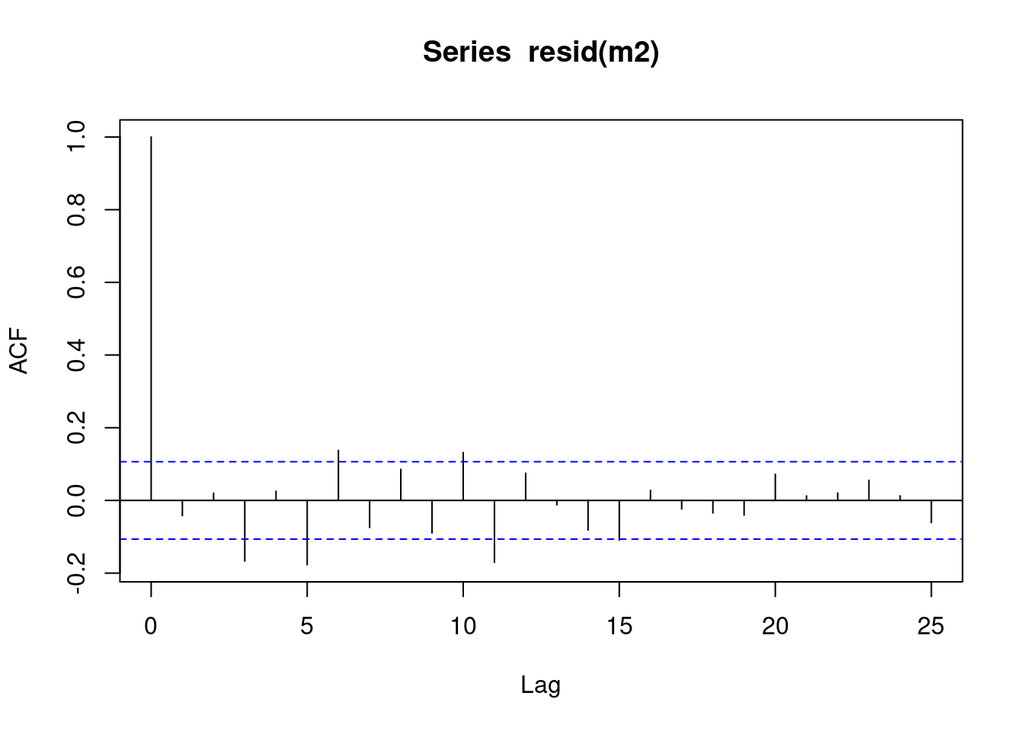

```r
acf(resid(m2)) # autocorrelation seems ok
```

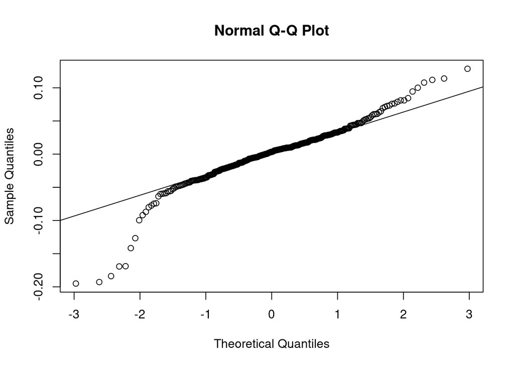

```r
qqnorm(resid(m2))
qqline(resid(m2)) # looks OKish
```

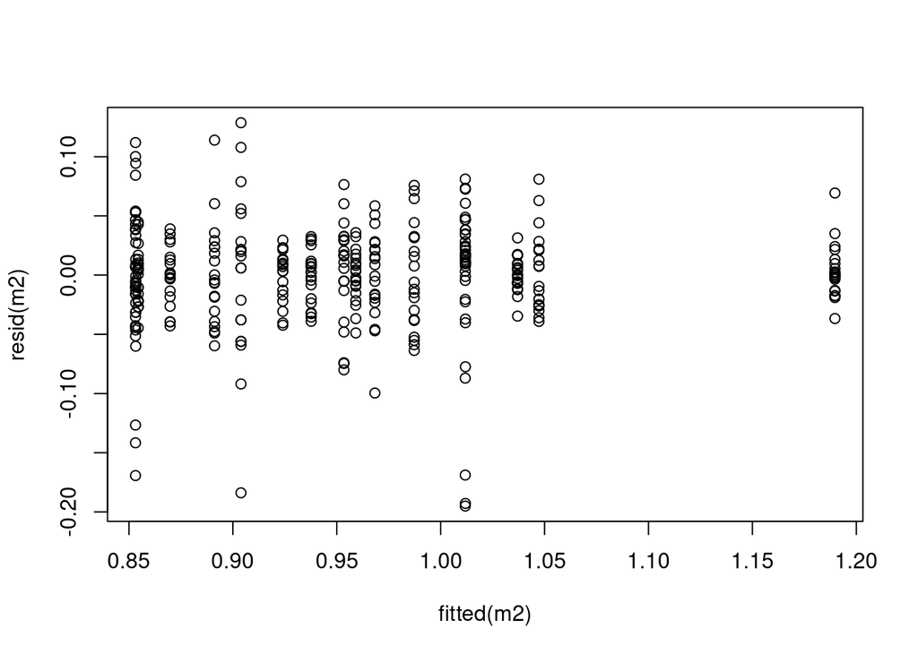

```r
plot(fitted(m2), resid(m2))
```

### MODELS FOR VAI PD ONLY

Model with only PD, state as fixed effect & random intercepts for subjects

```r
summary(m1PD <- lmer(VAI ~ state + (1|participant.id), data = data[data$group=="PD",]))
```

```
## Linear mixed model fit by REML. t-tests use Satterthwaite's method [
## lmerModLmerTest]
## Formula: VAI ~ state + (1 | participant.id)
##    Data: data[data$group == "PD", ]
##
## REML criterion at convergence: -598.3
##
## Scaled residuals:
##     Min      1Q  Median      3Q     Max
## -4.1273 -0.4375  0.0555  0.5022  2.7954
##
## Random effects:
##  Groups         Name        Variance Std.Dev.
##  participant.id (Intercept) 0.011342 0.1065
##  Residual                   0.002172 0.0466
## Number of obs: 199, groups:  participant.id, 10
##
## Fixed effects:
##               Estimate Std. Error         df t value Pr(>|t|)
## (Intercept)   0.941334   0.034474   9.694769  27.305  1.7e-10 ***
## stateON      -0.009348   0.008244 188.000754  -1.134    0.258
## ---
## Signif. codes:  0 '***' 0.001 '**' 0.01 '*' 0.05 '.' 0.1 ' ' 1
##
## Correlation of Fixed Effects:
##         (Intr)
## stateON -0.191
```

Model with only PD, session as fixed effect & random intercepts for subjects

```r
summary(m2PD <- lmer(VAI ~ session + (1|participant.id), data = data[data$group=="PD",]))
```

```
## Linear mixed model fit by REML. t-tests use Satterthwaite's method [
## lmerModLmerTest]
## Formula: VAI ~ session + (1 | participant.id)
##    Data: data[data$group == "PD", ]
##
## REML criterion at convergence: -578.4
##
## Scaled residuals:
##     Min      1Q  Median      3Q     Max
## -4.0064 -0.4403  0.0566  0.4938  2.5771
##
## Random effects:
##  Groups         Name        Variance Std.Dev.
##  participant.id (Intercept) 0.011334 0.10646
##  Residual                   0.002177 0.04665
## Number of obs: 199, groups:  participant.id, 10
##
## Fixed effects:
##                   Estimate Std. Error         df t value Pr(>|t|)
## (Intercept)      9.413e-01  3.446e-02  9.697e+00  27.313 1.69e-10 ***
## sessionmorning1 -1.473e-02  1.043e-02  1.850e+02  -1.412    0.160
## sessionmorning2 -1.296e-02  1.043e-02  1.850e+02  -1.242    0.216
## sessionevening1  7.524e-04  1.050e-02  1.850e+02   0.072    0.943
## sessionevening2 -1.019e-02  1.043e-02  1.850e+02  -0.977    0.330
## ---
## Signif. codes:  0 '***' 0.001 '**' 0.01 '*' 0.05 '.' 0.1 ' ' 1
##
## Correlation of Fixed Effects:
##             (Intr) sssnm1 sssnm2 sssnv1
## sessnmrnng1 -0.151
## sessnmrnng2 -0.151  0.500
## sessinvnng1 -0.150  0.497  0.497
## sessinvnng2 -0.151  0.500  0.500  0.497
```

```r
anova(m1PD, m2PD)
```

```
## refitting model(s) with ML (instead of REML)
```

```
## Data: data[data$group == "PD", ]
## Models:
## m1PD: VAI ~ state + (1 | participant.id)
## m2PD: VAI ~ session + (1 | participant.id)
##      npar     AIC     BIC logLik deviance  Chisq Df Pr(>Chisq)
## m1PD    4 -603.08 -589.90 305.54  -611.08
## m2PD    7 -599.73 -576.67 306.86  -613.73 2.6492  3     0.4489
```

```r
anova(m2PD)
```

```
## Type III Analysis of Variance Table with Satterthwaite's method
##            Sum Sq   Mean Sq NumDF DenDF F value Pr(>F)
## session 0.0084754 0.0021188     4   185  0.9735 0.4233
```

Stick with state.

Model with state and Gender as fixed effect & random intercepts for subjects

```r
summary(m3PD <- lmer(VAI ~ state + Gender + (1|participant.id), data = data[data$group=="PD",]))
```

```
## Linear mixed model fit by REML. t-tests use Satterthwaite's method [
## lmerModLmerTest]
## Formula: VAI ~ state + Gender + (1 | participant.id)
##    Data: data[data$group == "PD", ]
##
## REML criterion at convergence: -602.4
##
## Scaled residuals:
##     Min      1Q  Median      3Q     Max
## -4.0915 -0.4285  0.0582  0.5088  2.8054
##
## Random effects:
##  Groups         Name        Variance Std.Dev.
##  participant.id (Intercept) 0.005215 0.07221
##  Residual                   0.002172 0.04660
## Number of obs: 199, groups:  participant.id, 10
##
## Fixed effects:
##               Estimate Std. Error         df t value Pr(>|t|)
## (Intercept)   1.096855   0.052011   8.263232  21.089 1.77e-08 ***
## stateON      -0.009349   0.008244 188.002070  -1.134  0.25824
## Gendermale   -0.194402   0.057681   8.000153  -3.370  0.00978 **
## ---
## Signif. codes:  0 '***' 0.001 '**' 0.01 '*' 0.05 '.' 0.1 ' ' 1
##
## Correlation of Fixed Effects:
##            (Intr) statON
## stateON    -0.127
## Gendermale -0.887  0.000
```

```r
anova(m1PD, m3PD)
```

```
## refitting model(s) with ML (instead of REML)
```

```
## Data: data[data$group == "PD", ]
## Models:
## m1PD: VAI ~ state + (1 | participant.id)
## m3PD: VAI ~ state + Gender + (1 | participant.id)
##      npar     AIC     BIC logLik deviance  Chisq Df Pr(>Chisq)
## m1PD    4 -603.08 -589.90 305.54  -611.08
## m3PD    5 -609.92 -593.45 309.96  -619.92 8.8371  1   0.002952 **
## ---
## Signif. codes:  0 '***' 0.001 '**' 0.01 '*' 0.05 '.' 0.1 ' ' 1
```

```r
anova(m3PD)
```

```
## Type III Analysis of Variance Table with Satterthwaite's method
##           Sum Sq   Mean Sq NumDF DenDF F value   Pr(>F)
## state  0.0027931 0.0027931     1   188   1.286 0.258238
## Gender 0.0246711 0.0246711     1     8  11.359 0.009781 **
## ---
## Signif. codes:  0 '***' 0.001 '**' 0.01 '*' 0.05 '.' 0.1 ' ' 1
```

Model 3PD has sign. lower AIC

Now we add language to the model.

```r
summary(m4PD <- lmer(VAI ~ state + Gender + lang + (1|participant.id), data = data[data$group=="PD",]))
```

```
## Linear mixed model fit by REML. t-tests use Satterthwaite's method [
## lmerModLmerTest]
## Formula: VAI ~ state + Gender + lang + (1 | participant.id)
##    Data: data[data$group == "PD", ]
##
## REML criterion at convergence: -598.5
##
## Scaled residuals:
##     Min      1Q  Median      3Q     Max
## -4.0919 -0.4364  0.0545  0.5126  2.8092
##
## Random effects:
##  Groups         Name        Variance Std.Dev.
##  participant.id (Intercept) 0.005720 0.07563
##  Residual                   0.002172 0.04660
## Number of obs: 199, groups:  participant.id, 10
##
## Fixed effects:
##                 Estimate Std. Error         df t value Pr(>|t|)
## (Intercept)     1.110571   0.059758   7.172806  18.585 2.49e-07 ***
## stateON        -0.009347   0.008244 188.001111  -1.134   0.2583
## Gendermale     -0.190970   0.060672   6.999916  -3.148   0.0162 *
## langSlovenian  -0.027435   0.049541   7.001632  -0.554   0.5970
## ---
## Signif. codes:  0 '***' 0.001 '**' 0.01 '*' 0.05 '.' 0.1 ' ' 1
##
## Correlation of Fixed Effects:
##             (Intr) statON Gndrml
## stateON     -0.110
## Gendermale  -0.761  0.000
## langSlovenn -0.414  0.000 -0.102
```

```r
anova(m3PD, m4PD)
```

```
## refitting model(s) with ML (instead of REML)
```

```
## Data: data[data$group == "PD", ]
## Models:
## m3PD: VAI ~ state + Gender + (1 | participant.id)
## m4PD: VAI ~ state + Gender + lang + (1 | participant.id)
##      npar     AIC     BIC logLik deviance  Chisq Df Pr(>Chisq)
## m3PD    5 -609.92 -593.45 309.96  -619.92
## m4PD    6 -608.34 -588.58 310.17  -620.34 0.4289  1     0.5125
```

No improvement.

Add day to the model.

```r
summary(m5PD <- lmer(VAI ~ state + Gender + day + (1|participant.id), data = data[data$group=="PD",]))
```

```
## Linear mixed model fit by REML. t-tests use Satterthwaite's method [
## lmerModLmerTest]
## Formula: VAI ~ state + Gender + day + (1 | participant.id)
##    Data: data[data$group == "PD", ]
##
## REML criterion at convergence: -579.6
##
## Scaled residuals:
##     Min      1Q  Median      3Q     Max
## -4.1265 -0.4701  0.0278  0.4792  2.7225
##
## Random effects:
##  Groups         Name        Variance Std.Dev.
##  participant.id (Intercept) 0.005213 0.07220
##  Residual                   0.002202 0.04693
## Number of obs: 199, groups:  participant.id, 10
##
## Fixed effects:
##               Estimate Std. Error         df t value Pr(>|t|)
## (Intercept)   1.094939   0.052333   8.470895  20.923 1.37e-08 ***
## stateON      -0.009341   0.008301 185.002134  -1.125  0.26193
## Gendermale   -0.194394   0.057679   8.000158  -3.370  0.00978 **
## daysecond     0.004899   0.009385 185.001656   0.522  0.60227
## daythird      0.003095   0.009435 185.005447   0.328  0.74324
## dayfourth    -0.000355   0.009385 185.001656  -0.038  0.96986
## ---
## Signif. codes:  0 '***' 0.001 '**' 0.01 '*' 0.05 '.' 0.1 ' ' 1
##
## Correlation of Fixed Effects:
##            (Intr) statON Gndrml dyscnd dythrd
## stateON    -0.127
## Gendermale -0.882  0.000
## daysecond  -0.090  0.000  0.000
## daythird   -0.090  0.004  0.001  0.497
## dayfourth  -0.090  0.000  0.000  0.500  0.497
```

```r
anova(m3PD, m5PD)
```

```
## refitting model(s) with ML (instead of REML)
```

```
## Data: data[data$group == "PD", ]
## Models:
## m3PD: VAI ~ state + Gender + (1 | participant.id)
## m5PD: VAI ~ state + Gender + day + (1 | participant.id)
##      npar     AIC     BIC logLik deviance  Chisq Df Pr(>Chisq)
## m3PD    5 -609.92 -593.45 309.96  -619.92
## m5PD    8 -604.36 -578.01 310.18  -620.36 0.4425  3     0.9313
```

```r
anova(m5PD)
```

```
## Type III Analysis of Variance Table with Satterthwaite's method
##           Sum Sq   Mean Sq NumDF DenDF F value   Pr(>F)
## state  0.0027883 0.0027883     1   185  1.2662 0.261930
## Gender 0.0250124 0.0250124     1     8 11.3587 0.009782 **
## day    0.0009545 0.0003182     3   185  0.1445 0.933106
## ---
## Signif. codes:  0 '***' 0.001 '**' 0.01 '*' 0.05 '.' 0.1 ' ' 1
```

No improvement.

Add time of day to the model.

```r
summary(m6PD <- lmer(VAI ~ state + Gender + time + (1|participant.id), data = data[data$group=="PD",]))
```

```
## Linear mixed model fit by REML. t-tests use Satterthwaite's method [
## lmerModLmerTest]
## Formula: VAI ~ state + Gender + time + (1 | participant.id)
##    Data: data[data$group == "PD", ]
##
## REML criterion at convergence: -595.9
##
## Scaled residuals:
##     Min      1Q  Median      3Q     Max
## -4.0000 -0.4775  0.0918  0.4762  2.7118
##
## Random effects:
##  Groups         Name        Variance Std.Dev.
##  participant.id (Intercept) 0.005213 0.07220
##  Residual                   0.002166 0.04654
## Number of obs: 199, groups:  participant.id, 10
##
## Fixed effects:
##               Estimate Std. Error         df t value Pr(>|t|)
## (Intercept)   1.105881   0.052521   8.596910  21.056 1.07e-08 ***
## stateON      -0.013844   0.009013 187.001617  -1.536  0.12623
## Gendermale   -0.194372   0.057673   8.000158  -3.370  0.00978 **
## timemorning  -0.009050   0.007383 187.003940  -1.226  0.22186
## ---
## Signif. codes:  0 '***' 0.001 '**' 0.01 '*' 0.05 '.' 0.1 ' ' 1
##
## Correlation of Fixed Effects:
##             (Intr) statON Gndrml
## stateON     -0.172
## Gendermale  -0.878  0.000
## timemorning -0.140  0.407  0.000
```

```r
anova(m3PD, m6PD)
```

```
## refitting model(s) with ML (instead of REML)
```

```
## Data: data[data$group == "PD", ]
## Models:
## m3PD: VAI ~ state + Gender + (1 | participant.id)
## m6PD: VAI ~ state + Gender + time + (1 | participant.id)
##      npar     AIC     BIC logLik deviance  Chisq Df Pr(>Chisq)
## m3PD    5 -609.92 -593.45 309.96  -619.92
## m6PD    6 -609.43 -589.67 310.71  -621.43 1.5129  1     0.2187
```

No improvement.

Add levodopa

```r
summary(m7PD <- lmer(VAI ~ state + Gender + levodopa + (1|participant.id), data = data[data$group=="PD",]))
```

```
## Linear mixed model fit by REML. t-tests use Satterthwaite's method [
## lmerModLmerTest]
## Formula: VAI ~ state + Gender + levodopa + (1 | participant.id)
##    Data: data[data$group == "PD", ]
##
## REML criterion at convergence: -585.5
##
## Scaled residuals:
##     Min      1Q  Median      3Q     Max
## -4.0981 -0.4302  0.0525  0.5084  2.8050
##
## Random effects:
##  Groups         Name        Variance Std.Dev.
##  participant.id (Intercept) 0.005975 0.0773
##  Residual                   0.002172 0.0466
## Number of obs: 199, groups:  participant.id, 10
##
## Fixed effects:
##               Estimate Std. Error         df t value Pr(>|t|)
## (Intercept)  1.097e+00  6.377e-02  7.153e+00  17.196 4.42e-07 ***
## stateON     -9.349e-03  8.244e-03  1.880e+02  -1.134   0.2582
## Gendermale  -1.947e-01  6.954e-02  7.000e+00  -2.800   0.0265 *
## levodopa     9.263e-07  8.948e-05  7.001e+00   0.010   0.9920
## ---
## Signif. codes:  0 '***' 0.001 '**' 0.01 '*' 0.05 '.' 0.1 ' ' 1
##
## Correlation of Fixed Effects:
##            (Intr) statON Gndrml
## stateON    -0.104
## Gendermale -0.459  0.000
## levodopa   -0.491  0.000 -0.462
```

```r
anova(m3PD,m7PD)
```

```
## refitting model(s) with ML (instead of REML)
```

```
## Data: data[data$group == "PD", ]
## Models:
## m3PD: VAI ~ state + Gender + (1 | participant.id)
## m7PD: VAI ~ state + Gender + levodopa + (1 | participant.id)
##      npar     AIC     BIC logLik deviance Chisq Df Pr(>Chisq)
## m3PD    5 -609.92 -593.45 309.96  -619.92
## m7PD    6 -607.92 -588.16 309.96  -619.92 2e-04  1     0.9901
```

No improvement.

Add diagnosis

```r
summary(m8PD <- lmer(VAI ~ state + Gender + diagnosis + (1|participant.id), data = data[data$group=="PD",]))
```

```
## Linear mixed model fit by REML. t-tests use Satterthwaite's method [
## lmerModLmerTest]
## Formula: VAI ~ state + Gender + diagnosis + (1 | participant.id)
##    Data: data[data$group == "PD", ]
##
## REML criterion at convergence: -598.3
##
## Scaled residuals:
##     Min      1Q  Median      3Q     Max
## -4.1182 -0.4516  0.0534  0.5215  2.8150
##
## Random effects:
##  Groups         Name        Variance Std.Dev.
##  participant.id (Intercept) 0.003756 0.06129
##  Residual                   0.002172 0.04660
## Number of obs: 199, groups:  participant.id, 10
##
## Fixed effects:
##               Estimate Std. Error         df t value Pr(>|t|)
## (Intercept)   1.024523   0.057251   7.189156  17.895 3.17e-07 ***
## stateON      -0.009350   0.008244 188.003064  -1.134  0.25818
## Gendermale   -0.262215   0.059665   7.000639  -4.395  0.00318 **
## diagnosis     0.018083   0.009020   7.000122   2.005  0.08503 .
## ---
## Signif. codes:  0 '***' 0.001 '**' 0.01 '*' 0.05 '.' 0.1 ' ' 1
##
## Correlation of Fixed Effects:
##            (Intr) statON Gndrml
## stateON    -0.115
## Gendermale -0.208  0.000
## diagnosis  -0.630  0.000 -0.567
```

```r
anova(m3PD,m8PD)
```

```
## refitting model(s) with ML (instead of REML)
```

```
## Data: data[data$group == "PD", ]
## Models:
## m3PD: VAI ~ state + Gender + (1 | participant.id)
## m8PD: VAI ~ state + Gender + diagnosis + (1 | participant.id)
##      npar     AIC     BIC logLik deviance  Chisq Df Pr(>Chisq)
## m3PD    5 -609.92 -593.45 309.96  -619.92
## m8PD    6 -612.45 -592.69 312.23  -624.45 4.5369  1    0.03317 *
## ---
## Signif. codes:  0 '***' 0.001 '**' 0.01 '*' 0.05 '.' 0.1 ' ' 1
```

```r
summary(m8PD)
```

```
## Linear mixed model fit by REML. t-tests use Satterthwaite's method [
## lmerModLmerTest]
## Formula: VAI ~ state + Gender + diagnosis + (1 | participant.id)
##    Data: data[data$group == "PD", ]
##
## REML criterion at convergence: -598.3
##
## Scaled residuals:
##     Min      1Q  Median      3Q     Max
## -4.1182 -0.4516  0.0534  0.5215  2.8150
##
## Random effects:
##  Groups         Name        Variance Std.Dev.
##  participant.id (Intercept) 0.003756 0.06129
##  Residual                   0.002172 0.04660
## Number of obs: 199, groups:  participant.id, 10
##
## Fixed effects:
##               Estimate Std. Error         df t value Pr(>|t|)
## (Intercept)   1.024523   0.057251   7.189156  17.895 3.17e-07 ***
## stateON      -0.009350   0.008244 188.003064  -1.134  0.25818
## Gendermale   -0.262215   0.059665   7.000639  -4.395  0.00318 **
## diagnosis     0.018083   0.009020   7.000122   2.005  0.08503 .
## ---
## Signif. codes:  0 '***' 0.001 '**' 0.01 '*' 0.05 '.' 0.1 ' ' 1
##
## Correlation of Fixed Effects:
##            (Intr) statON Gndrml
## stateON    -0.115
## Gendermale -0.208  0.000
## diagnosis  -0.630  0.000 -0.567
```

Sign improvement in model comparison, but no sign effect of predictor when fitted with REML (p=0.09).

Add age

```r
summary(m9PD <- lmer(VAI ~ state + Gender + age + (1|participant.id), data = data[data$group=="PD",]))
```

```
## Linear mixed model fit by REML. t-tests use Satterthwaite's method [
## lmerModLmerTest]
## Formula: VAI ~ state + Gender + age + (1 | participant.id)
##    Data: data[data$group == "PD", ]
##
## REML criterion at convergence: -593.6
##
## Scaled residuals:
##     Min      1Q  Median      3Q     Max
## -4.0950 -0.4270  0.0711  0.5013  2.7961
##
## Random effects:
##  Groups         Name        Variance Std.Dev.
##  participant.id (Intercept) 0.005169 0.0719
##  Residual                   0.002172 0.0466
## Number of obs: 199, groups:  participant.id, 10
##
## Fixed effects:
##               Estimate Std. Error         df t value Pr(>|t|)
## (Intercept)   1.298059   0.201408   7.023764   6.445 0.000347 ***
## stateON      -0.009357   0.008244 188.000379  -1.135 0.257845
## Gendermale   -0.201973   0.057898   7.000567  -3.488 0.010149 *
## age          -0.003026   0.002927   7.008478  -1.034 0.335599
## ---
## Signif. codes:  0 '***' 0.001 '**' 0.01 '*' 0.05 '.' 0.1 ' ' 1
##
## Correlation of Fixed Effects:
##            (Intr) statON Gndrml
## stateON    -0.034
## Gendermale -0.349  0.000
## age        -0.966  0.001  0.127
```

```r
anova(m3PD,m9PD)
```

```
## refitting model(s) with ML (instead of REML)
```

```
## Data: data[data$group == "PD", ]
## Models:
## m3PD: VAI ~ state + Gender + (1 | participant.id)
## m9PD: VAI ~ state + Gender + age + (1 | participant.id)
##      npar     AIC     BIC logLik deviance  Chisq Df Pr(>Chisq)
## m3PD    5 -609.92 -593.45 309.96  -619.92
## m9PD    6 -609.34 -589.58 310.67  -621.34 1.4207  1     0.2333
```

No improvement.

## Interactions

Add state*Gender

```r
summary(m10PD <- lmer(VAI ~ state*Gender + (1|participant.id), data = data[data$group=="PD",]))
```

```
## Linear mixed model fit by REML. t-tests use Satterthwaite's method [
## lmerModLmerTest]
## Formula: VAI ~ state * Gender + (1 | participant.id)
##    Data: data[data$group == "PD", ]
##
## REML criterion at convergence: -596.7
##
## Scaled residuals:
##     Min      1Q  Median      3Q     Max
## -4.0743 -0.4234  0.0589  0.5150  2.8085
##
## Random effects:
##  Groups         Name        Variance Std.Dev.
##  participant.id (Intercept) 0.005214 0.07221
##  Residual                   0.002181 0.04670
## Number of obs: 199, groups:  participant.id, 10
##
## Fixed effects:
##                      Estimate Std. Error         df t value Pr(>|t|)
## (Intercept)          1.090339   0.053664   9.361581  20.318 4.63e-09 ***
## stateON             -0.001204   0.018459 187.001613  -0.065   0.9481
## Gendermale          -0.186256   0.059998   9.361581  -3.104   0.0121 *
## stateON:Gendermale  -0.010185   0.020641 187.001729  -0.493   0.6223
## ---
## Signif. codes:  0 '***' 0.001 '**' 0.01 '*' 0.05 '.' 0.1 ' ' 1
##
## Correlation of Fixed Effects:
##             (Intr) statON Gndrml
## stateON     -0.275
## Gendermale  -0.894  0.246
## sttON:Gndrm  0.246 -0.894 -0.275
```

```r
anova(m10PD, m3PD)
```

```
## refitting model(s) with ML (instead of REML)
```

```
## Data: data[data$group == "PD", ]
## Models:
## m3PD: VAI ~ state + Gender + (1 | participant.id)
## m10PD: VAI ~ state * Gender + (1 | participant.id)
##       npar     AIC     BIC logLik deviance  Chisq Df Pr(>Chisq)
## m3PD     5 -609.92 -593.45 309.96  -619.92
## m10PD    6 -608.16 -588.40 310.08  -620.16 0.2459  1       0.62
```

No improvement.

Add state*language

```r
summary(m11PD <- lmer(VAI ~ state*lang + Gender + (1|participant.id), data = data[data$group=="PD",]))
```

```
## Linear mixed model fit by REML. t-tests use Satterthwaite's method [
## lmerModLmerTest]
## Formula: VAI ~ state * lang + Gender + (1 | participant.id)
##    Data: data[data$group == "PD", ]
##
## REML criterion at convergence: -594.3
##
## Scaled residuals:
##     Min      1Q  Median      3Q     Max
## -4.0625 -0.4742  0.0435  0.5110  2.8609
##
## Random effects:
##  Groups         Name        Variance Std.Dev.
##  participant.id (Intercept) 0.005718 0.07562
##  Residual                   0.002158 0.04646
## Number of obs: 199, groups:  participant.id, 10
##
## Fixed effects:
##                         Estimate Std. Error         df t value Pr(>|t|)
## (Intercept)             1.098616   0.060286   7.434367  18.224 1.93e-07 ***
## stateON                 0.005622   0.013006 187.001621   0.432   0.6661
## langSlovenian          -0.007544   0.051313   8.061690  -0.147   0.8867
## Gendermale             -0.190946   0.060662   6.999915  -3.148   0.0162 *
## stateON:langSlovenian  -0.024916   0.016780 187.001280  -1.485   0.1393
## ---
## Signif. codes:  0 '***' 0.001 '**' 0.01 '*' 0.05 '.' 0.1 ' ' 1
##
## Correlation of Fixed Effects:
##             (Intr) statON lngSlv Gndrml
## stateON     -0.172
## langSlovenn -0.431  0.202
## Gendermale  -0.755  0.000 -0.099
## sttON:lngSl  0.134 -0.775 -0.261  0.000
```

```r
anova(m3PD, m11PD)
```

```
## refitting model(s) with ML (instead of REML)
```

```
## Data: data[data$group == "PD", ]
## Models:
## m3PD: VAI ~ state + Gender + (1 | participant.id)
## m11PD: VAI ~ state * lang + Gender + (1 | participant.id)
##       npar     AIC     BIC logLik deviance  Chisq Df Pr(>Chisq)
## m3PD     5 -609.92 -593.45 309.96  -619.92
## m11PD    7 -608.56 -585.51 311.28  -622.56 2.6452  2     0.2664
```

No improvement.

Add state*day interaction

```r
summary(m12PD <- lmer(VAI ~ state*day + Gender + (1|participant.id), data = data[data$group=="PD",]))
```

```
## Linear mixed model fit by REML. t-tests use Satterthwaite's method [
## lmerModLmerTest]
## Formula: VAI ~ state * day + Gender + (1 | participant.id)
##    Data: data[data$group == "PD", ]
##
## REML criterion at convergence: -563.2
##
## Scaled residuals:
##     Min      1Q  Median      3Q     Max
## -4.1513 -0.5145  0.0536  0.5101  2.6660
##
## Random effects:
##  Groups         Name        Variance Std.Dev.
##  participant.id (Intercept) 0.005212 0.07219
##  Residual                   0.002222 0.04714
## Number of obs: 199, groups:  participant.id, 10
##
## Fixed effects:
##                     Estimate Std. Error         df t value Pr(>|t|)
## (Intercept)         1.107019   0.053597   9.317005  20.654 4.26e-09 ***
## stateON            -0.024440   0.016667 182.001677  -1.466  0.14427
## daysecond          -0.015499   0.021082 182.001677  -0.735  0.46317
## daythird           -0.008482   0.021082 182.001677  -0.402  0.68790
## dayfourth          -0.016697   0.021082 182.001677  -0.792  0.42940
## Gendermale         -0.194395   0.057679   8.000160  -3.370  0.00978 **
## stateON:daysecond   0.025499   0.023571 182.001677   1.082  0.28078
## stateON:daythird    0.014469   0.023602 182.002634   0.613  0.54063
## stateON:dayfourth   0.020427   0.023571 182.001677   0.867  0.38729
## ---
## Signif. codes:  0 '***' 0.001 '**' 0.01 '*' 0.05 '.' 0.1 ' ' 1
##
## Correlation of Fixed Effects:
##             (Intr) statON dyscnd dythrd dyfrth Gndrml sttON:dys sttON:dyt
## stateON     -0.249
## daysecond   -0.197  0.632
## daythird    -0.197  0.632  0.500
## dayfourth   -0.197  0.632  0.500  0.500
## Gendermale  -0.861  0.000  0.000  0.000  0.000
## sttON:dyscn  0.176 -0.707 -0.894 -0.447 -0.447  0.000
## sttON:dythr  0.175 -0.706 -0.447 -0.893 -0.447  0.000  0.499
## sttON:dyfrt  0.176 -0.707 -0.447 -0.447 -0.894  0.000  0.500     0.499
```

```r
anova(m3PD, m12PD)
```

```
## refitting model(s) with ML (instead of REML)
```

```
## Data: data[data$group == "PD", ]
## Models:
## m3PD: VAI ~ state + Gender + (1 | participant.id)
## m12PD: VAI ~ state * day + Gender + (1 | participant.id)
##       npar     AIC     BIC logLik deviance  Chisq Df Pr(>Chisq)
## m3PD     5 -609.92 -593.45 309.96  -619.92
## m12PD   11 -599.72 -563.49 310.86  -621.72 1.8017  6      0.937
```

```r
anova(m12PD)
```

```
## Type III Analysis of Variance Table with Satterthwaite's method
##              Sum Sq   Mean Sq NumDF DenDF F value   Pr(>F)
## state     0.0027888 0.0027888     1   182  1.2549 0.264092
## day       0.0007577 0.0002526     3   182  0.1136 0.952032
## Gender    0.0252425 0.0252425     1     8 11.3586 0.009782 **
## state:day 0.0029193 0.0009731     3   182  0.4379 0.726166
## ---
## Signif. codes:  0 '***' 0.001 '**' 0.01 '*' 0.05 '.' 0.1 ' ' 1
```

No added value.

Add lang*time interaction

```r
summary(m13PD <- lmer(VAI ~ state + Gender + lang*time + (1|participant.id), data = data[data$group=="PD",]))
```

```
## Linear mixed model fit by REML. t-tests use Satterthwaite's method [
## lmerModLmerTest]
## Formula: VAI ~ state + Gender + lang * time + (1 | participant.id)
##    Data: data[data$group == "PD", ]
##
## REML criterion at convergence: -585.3
##
## Scaled residuals:
##     Min      1Q  Median      3Q     Max
## -4.0005 -0.4830  0.0809  0.4810  2.7245
##
## Random effects:
##  Groups         Name        Variance Std.Dev.
##  participant.id (Intercept) 0.005716 0.07560
##  Residual                   0.002177 0.04666
## Number of obs: 199, groups:  participant.id, 10
##
## Fixed effects:
##                             Estimate Std. Error         df t value Pr(>|t|)
## (Intercept)                 1.120775   0.060409   7.499944  18.553 1.54e-07 ***
## stateON                    -0.013844   0.009036 186.000790  -1.532   0.1272
## Gendermale                 -0.190923   0.060653   6.999917  -3.148   0.0162 *
## langSlovenian              -0.029392   0.050228   7.406858  -0.585   0.5758
## timemorning                -0.010946   0.011169 186.005636  -0.980   0.3283
## langSlovenian:timemorning   0.003130   0.013830 186.003951   0.226   0.8212
## ---
## Signif. codes:  0 '***' 0.001 '**' 0.01 '*' 0.05 '.' 0.1 ' ' 1
##
## Correlation of Fixed Effects:
##             (Intr) statON Gndrml lngSlv tmmrnn
## stateON     -0.150
## Gendermale  -0.753  0.000
## langSlovenn -0.418  0.000 -0.101
## timemorning -0.144  0.270 -0.001  0.125
## lngSlvnn:tm  0.084  0.000  0.001 -0.167 -0.749
```

```r
anova(m3PD, m13PD)
```

```
## refitting model(s) with ML (instead of REML)
```

```
## Data: data[data$group == "PD", ]
## Models:
## m3PD: VAI ~ state + Gender + (1 | participant.id)
## m13PD: VAI ~ state + Gender + lang * time + (1 | participant.id)
##       npar     AIC     BIC logLik deviance  Chisq Df Pr(>Chisq)
## m3PD     5 -609.92 -593.45 309.96  -619.92
## m13PD    8 -605.91 -579.57 310.96  -621.91 1.9963  3     0.5732
```

No improvement.

Add gender*language interaction

```r
summary(m14PD <- lmer(VAI ~ state + Gender*lang + (1|participant.id), data = data[data$group=="PD",]))
```

```
## Linear mixed model fit by REML. t-tests use Satterthwaite's method [
## lmerModLmerTest]
## Formula: VAI ~ state + Gender * lang + (1 | participant.id)
##    Data: data[data$group == "PD", ]
##
## REML criterion at convergence: -600.3
##
## Scaled residuals:
##     Min      1Q  Median      3Q     Max
## -4.0675 -0.4298  0.0590  0.5125  2.8024
##
## Random effects:
##  Groups         Name        Variance Std.Dev.
##  participant.id (Intercept) 0.003301 0.05746
##  Residual                   0.002172 0.04660
## Number of obs: 199, groups:  participant.id, 10
##
## Fixed effects:
##                            Estimate Std. Error         df t value Pr(>|t|)
## (Intercept)                1.200174   0.058765   6.153841  20.423 6.89e-07 ***
## stateON                   -0.009349   0.008244 188.002612  -1.134  0.25820
## Gendermale                -0.310445   0.067432   6.001499  -4.604  0.00367 **
## langSlovenian             -0.206636   0.082581   5.999824  -2.502  0.04639 *
## Gendermale:langSlovenian   0.226995   0.092945   6.000706   2.442  0.05031 .
## ---
## Signif. codes:  0 '***' 0.001 '**' 0.01 '*' 0.05 '.' 0.1 ' ' 1
##
## Correlation of Fixed Effects:
##             (Intr) statON Gndrml lngSlv
## stateON     -0.112
## Gendermale  -0.861  0.000
## langSlovenn -0.703  0.000  0.612
## Gndrml:lngS  0.624  0.000 -0.726 -0.888
```

```r
anova(m3PD, m14PD)
```

```
## refitting model(s) with ML (instead of REML)
```

```
## Data: data[data$group == "PD", ]
## Models:
## m3PD: VAI ~ state + Gender + (1 | participant.id)
## m14PD: VAI ~ state + Gender * lang + (1 | participant.id)
##       npar     AIC     BIC logLik deviance  Chisq Df Pr(>Chisq)
## m3PD     5 -609.92 -593.45 309.96  -619.92
## m14PD    7 -613.25 -590.19 313.62  -627.25 7.3305  2     0.0256 *
## ---
## Signif. codes:  0 '***' 0.001 '**' 0.01 '*' 0.05 '.' 0.1 ' ' 1
```

```r
summary(m14PD)
```

```
## Linear mixed model fit by REML. t-tests use Satterthwaite's method [
## lmerModLmerTest]
## Formula: VAI ~ state + Gender * lang + (1 | participant.id)
##    Data: data[data$group == "PD", ]
##
## REML criterion at convergence: -600.3
##
## Scaled residuals:
##     Min      1Q  Median      3Q     Max
## -4.0675 -0.4298  0.0590  0.5125  2.8024
##
## Random effects:
##  Groups         Name        Variance Std.Dev.
##  participant.id (Intercept) 0.003301 0.05746
##  Residual                   0.002172 0.04660
## Number of obs: 199, groups:  participant.id, 10
##
## Fixed effects:
##                            Estimate Std. Error         df t value Pr(>|t|)
## (Intercept)                1.200174   0.058765   6.153841  20.423 6.89e-07 ***
## stateON                   -0.009349   0.008244 188.002612  -1.134  0.25820
## Gendermale                -0.310445   0.067432   6.001499  -4.604  0.00367 **
## langSlovenian             -0.206636   0.082581   5.999824  -2.502  0.04639 *
## Gendermale:langSlovenian   0.226995   0.092945   6.000706   2.442  0.05031 .
## ---
## Signif. codes:  0 '***' 0.001 '**' 0.01 '*' 0.05 '.' 0.1 ' ' 1
##
## Correlation of Fixed Effects:
##             (Intr) statON Gndrml lngSlv
## stateON     -0.112
## Gendermale  -0.861  0.000
## langSlovenn -0.703  0.000  0.612
## Gndrml:lngS  0.624  0.000 -0.726 -0.888
```

Significant, but not reliable since there was only one female in the Dutch sample.

Add age*language interaction

```r
m15PD <- lmer(VAI ~ state + Gender + lang*age + (1|participant.id), data = data[data$group=="PD",])
anova(m3PD, m15PD)
```

```
## refitting model(s) with ML (instead of REML)
```

```
## Data: data[data$group == "PD", ]
## Models:
## m3PD: VAI ~ state + Gender + (1 | participant.id)
## m15PD: VAI ~ state + Gender + lang * age + (1 | participant.id)
##       npar     AIC     BIC logLik deviance  Chisq Df Pr(>Chisq)
## m3PD     5 -609.92 -593.45 309.96  -619.92
## m15PD    8 -608.79 -582.44 312.39  -624.79 4.8706  3     0.1815
```

No improvement.

Add state*time of day interaction

```r
summary(m16PD <- lmer(VAI ~ state*time + Gender + (1|participant.id), data = data[data$group=="PD",]))
```

```
## fixed-effect model matrix is rank deficient so dropping 1 column / coefficient
```

```
## Linear mixed model fit by REML. t-tests use Satterthwaite's method [
## lmerModLmerTest]
## Formula: VAI ~ state * time + Gender + (1 | participant.id)
##    Data: data[data$group == "PD", ]
##
## REML criterion at convergence: -595.9
##
## Scaled residuals:
##     Min      1Q  Median      3Q     Max
## -4.0000 -0.4775  0.0918  0.4762  2.7118
##
## Random effects:
##  Groups         Name        Variance Std.Dev.
##  participant.id (Intercept) 0.005213 0.07220
##  Residual                   0.002166 0.04654
## Number of obs: 199, groups:  participant.id, 10
##
## Fixed effects:
##               Estimate Std. Error         df t value Pr(>|t|)
## (Intercept)   1.105881   0.052521   8.596910  21.056 1.07e-08 ***
## stateON      -0.013844   0.009013 187.001617  -1.536  0.12623
## timemorning  -0.009050   0.007383 187.003940  -1.226  0.22186
## Gendermale   -0.194372   0.057673   8.000158  -3.370  0.00978 **
## ---
## Signif. codes:  0 '***' 0.001 '**' 0.01 '*' 0.05 '.' 0.1 ' ' 1
##
## Correlation of Fixed Effects:
##             (Intr) statON tmmrnn
## stateON     -0.172
## timemorning -0.140  0.407
## Gendermale  -0.878  0.000  0.000
## fit warnings:
## fixed-effect model matrix is rank deficient so dropping 1 column / coefficient
```

```r
anova(m3PD, m16PD)
```

```
## refitting model(s) with ML (instead of REML)
```

```
## Data: data[data$group == "PD", ]
## Models:
## m3PD: VAI ~ state + Gender + (1 | participant.id)
## m16PD: VAI ~ state * time + Gender + (1 | participant.id)
##       npar     AIC     BIC logLik deviance  Chisq Df Pr(>Chisq)
## m3PD     5 -609.92 -593.45 309.96  -619.92
## m16PD    6 -609.43 -589.67 310.71  -621.43 1.5129  1     0.2187
```

No improvement.

```r
summary(m17PD <- lmer(VAI ~ state*day + Gender + (1|participant.id), data = data[data$group=="PD",]))
```

```
## Linear mixed model fit by REML. t-tests use Satterthwaite's method [
## lmerModLmerTest]
## Formula: VAI ~ state * day + Gender + (1 | participant.id)
##    Data: data[data$group == "PD", ]
##
## REML criterion at convergence: -563.2
##
## Scaled residuals:
##     Min      1Q  Median      3Q     Max
## -4.1513 -0.5145  0.0536  0.5101  2.6660
##
## Random effects:
##  Groups         Name        Variance Std.Dev.
##  participant.id (Intercept) 0.005212 0.07219
##  Residual                   0.002222 0.04714
## Number of obs: 199, groups:  participant.id, 10
##
## Fixed effects:
##                     Estimate Std. Error         df t value Pr(>|t|)
## (Intercept)         1.107019   0.053597   9.317005  20.654 4.26e-09 ***
## stateON            -0.024440   0.016667 182.001677  -1.466  0.14427
## daysecond          -0.015499   0.021082 182.001677  -0.735  0.46317
## daythird           -0.008482   0.021082 182.001677  -0.402  0.68790
## dayfourth          -0.016697   0.021082 182.001677  -0.792  0.42940
## Gendermale         -0.194395   0.057679   8.000160  -3.370  0.00978 **
## stateON:daysecond   0.025499   0.023571 182.001677   1.082  0.28078
## stateON:daythird    0.014469   0.023602 182.002634   0.613  0.54063
## stateON:dayfourth   0.020427   0.023571 182.001677   0.867  0.38729
## ---
## Signif. codes:  0 '***' 0.001 '**' 0.01 '*' 0.05 '.' 0.1 ' ' 1
##
## Correlation of Fixed Effects:
##             (Intr) statON dyscnd dythrd dyfrth Gndrml sttON:dys sttON:dyt
## stateON     -0.249
## daysecond   -0.197  0.632
## daythird    -0.197  0.632  0.500
## dayfourth   -0.197  0.632  0.500  0.500
## Gendermale  -0.861  0.000  0.000  0.000  0.000
## sttON:dyscn  0.176 -0.707 -0.894 -0.447 -0.447  0.000
## sttON:dythr  0.175 -0.706 -0.447 -0.893 -0.447  0.000  0.499
## sttON:dyfrt  0.176 -0.707 -0.447 -0.447 -0.894  0.000  0.500     0.499
```

```r
anova(m3PD, m17PD)
```

```
## refitting model(s) with ML (instead of REML)
```

```
## Data: data[data$group == "PD", ]
## Models:
## m3PD: VAI ~ state + Gender + (1 | participant.id)
## m17PD: VAI ~ state * day + Gender + (1 | participant.id)
##       npar     AIC     BIC logLik deviance  Chisq Df Pr(>Chisq)
## m3PD     5 -609.92 -593.45 309.96  -619.92
## m17PD   11 -599.72 -563.49 310.86  -621.72 1.8017  6      0.937
```

```r
anova(m17PD)
```

```
## Type III Analysis of Variance Table with Satterthwaite's method
##              Sum Sq   Mean Sq NumDF DenDF F value   Pr(>F)
## state     0.0027888 0.0027888     1   182  1.2549 0.264092
## day       0.0007577 0.0002526     3   182  0.1136 0.952032
## Gender    0.0252425 0.0252425     1     8 11.3586 0.009782 **
## state:day 0.0029193 0.0009731     3   182  0.4379 0.726166
## ---
## Signif. codes:  0 '***' 0.001 '**' 0.01 '*' 0.05 '.' 0.1 ' ' 1
```

## Random slopes

```r
m3PDrandslo_state <- lmer(VAI ~ state + Gender + (1+state|participant.id), data = data[data$group=="PD",])
```

```
## boundary (singular) fit: see ?isSingular
```

```r
m3PDrandslo_time <- lmer(VAI ~ state + Gender  + (1+time|participant.id), data = data[data$group=="PD",])
```

```
## boundary (singular) fit: see ?isSingular
```

```r
m3PDrandslo_session <- lmer(VAI ~ state + Gender  + (1+session|participant.id), data = data[data$group=="PD",]) # singular fit
```

```
## boundary (singular) fit: see ?isSingular
```

```r
anova(m3PD, m3PDrandslo_state)
```

```
## refitting model(s) with ML (instead of REML)
```

```
## Data: data[data$group == "PD", ]
## Models:
## m3PD: VAI ~ state + Gender + (1 | participant.id)
## m3PDrandslo_state: VAI ~ state + Gender + (1 + state | participant.id)
##                   npar     AIC     BIC logLik deviance  Chisq Df Pr(>Chisq)
## m3PD                 5 -609.92 -593.45 309.96  -619.92
## m3PDrandslo_state    7 -605.93 -582.88 309.97  -619.93 0.0168  2     0.9917
```

```r
anova(m3PD, m3PDrandslo_time)
```

```
## refitting model(s) with ML (instead of REML)
```

```
## Data: data[data$group == "PD", ]
## Models:
## m3PD: VAI ~ state + Gender + (1 | participant.id)
## m3PDrandslo_time: VAI ~ state + Gender + (1 + time | participant.id)
##                  npar     AIC     BIC logLik deviance  Chisq Df Pr(>Chisq)
## m3PD                5 -609.92 -593.45 309.96  -619.92
## m3PDrandslo_time    7 -608.88 -585.83 311.44  -622.88 2.9688  2     0.2266
```

No improvements.

# Check assumptions final model

```r
lme.dscore(m3PD, data, type="lme4")
```

```
##                     t        df           d
## stateON    -0.3013579 245.00158 -0.03850597
## Gendermale -2.9394234  11.00067 -1.77248539
```

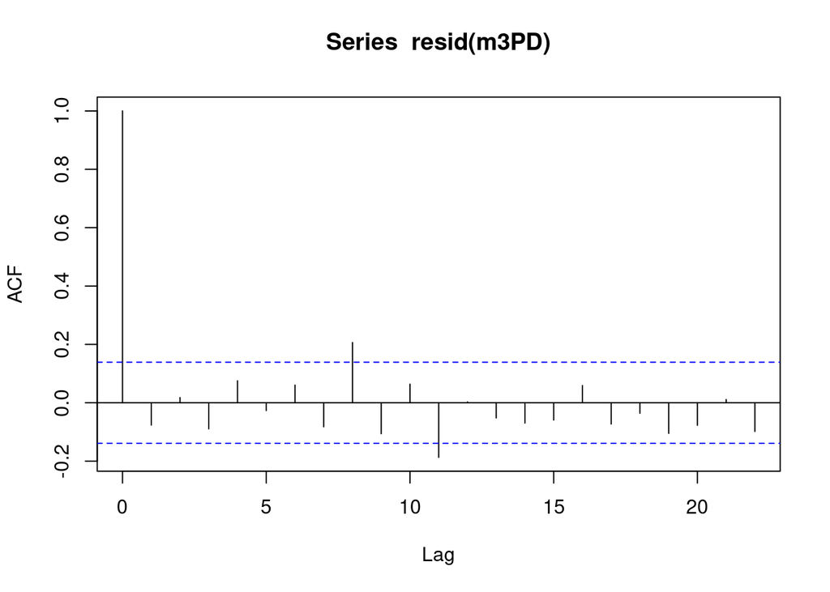

```r
acf(resid(m3PD)) # autocorrelation seems ok
```

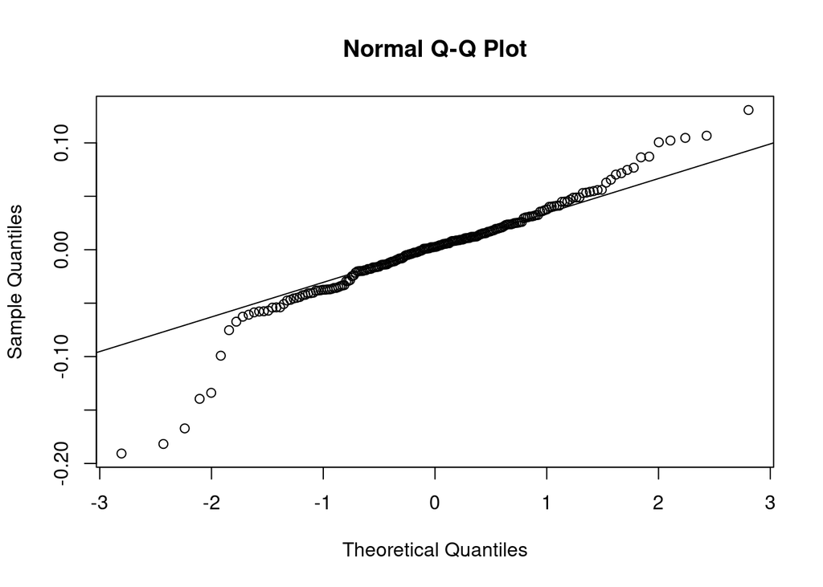

```r
qqnorm(resid(m3PD))
qqline(resid(m3PD)) # looks OK
```

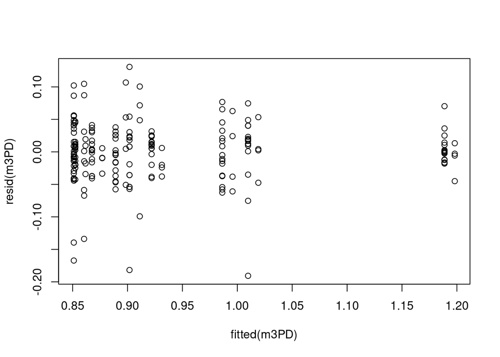

```r
plot(fitted(m3PD), resid(m3PD)) # looks OKish
```

### Fatigue

```r
m1PDf <- lmer(VAI ~ state + (1|participant.id), data = data[data$group=="PD" & data$lang == "Slovenian",])
```

```r
m2PDf <- lmer(VAI ~ state + fatigue + (1|participant.id), data = data[data$group=="PD" & data$lang == "Slovenian",])
anova(m1PDf, m2PDf)
```

```
## refitting model(s) with ML (instead of REML)
```

```
## Data: data[data$group == "PD" & data$lang == "Slovenian", ]
## Models:
## m1PDf: VAI ~ state + (1 | participant.id)
## m2PDf: VAI ~ state + fatigue + (1 | participant.id)
##       npar     AIC     BIC logLik deviance  Chisq Df Pr(>Chisq)
## m1PDf    4 -321.93 -310.78 164.96  -329.93
## m2PDf    5 -320.15 -306.21 165.07  -330.15 0.2244  1     0.6357
```

### plots

```
## No summary function supplied, defaulting to `mean_se()`
## No summary function supplied, defaulting to `mean_se()`
## No summary function supplied, defaulting to `mean_se()`
## No summary function supplied, defaulting to `mean_se()`
```

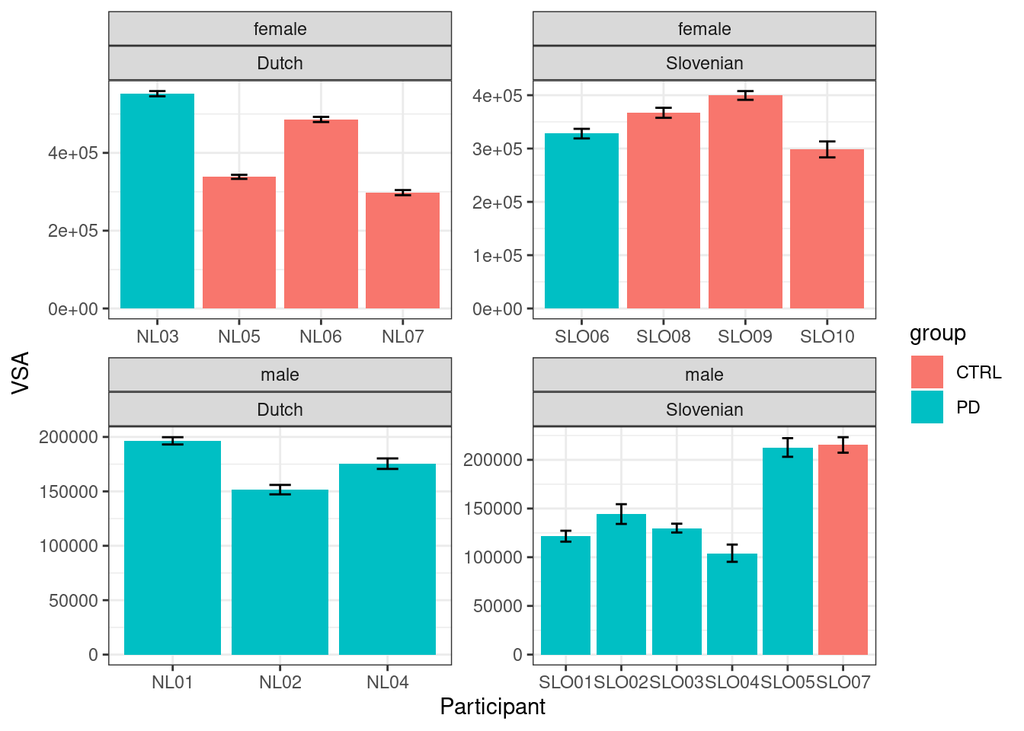

```r
ggplot(data=data, aes(x=participant.id, y=VSA, fill=group)) +
  geom_bar(stat="summary", fun.y=mean, position='dodge') +
   stat_summary(fun.data = "mean_se", geom = 'errorbar', position=position_dodge(.9), width = 0.2) +   #stat_summary(aes(label=group), fun.y=mean, geom="text", size=2) +
  #facet_wrap(Gender~lang, nrow = 1, scales = "free") +
  facet_wrap(Gender~lang, scales = "free")+
  labs(x = "Participant") +
  theme_bw()
```

```
## No summary function supplied, defaulting to `mean_se()`
## No summary function supplied, defaulting to `mean_se()`
## No summary function supplied, defaulting to `mean_se()`
## No summary function supplied, defaulting to `mean_se()`
```

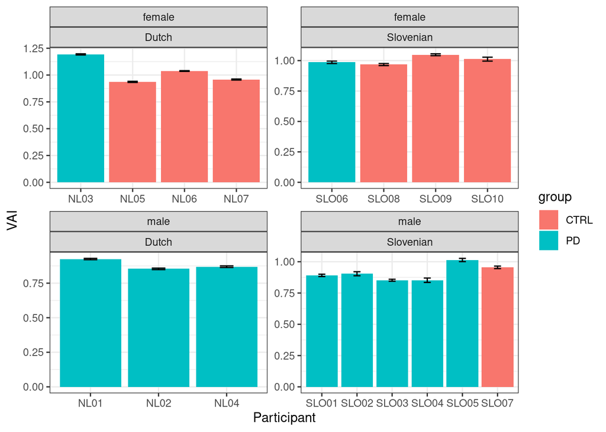

```r
ggplot(data=data, aes(x=participant.id, y=VAI, fill=group)) +
  geom_bar(stat="summary", fun.y=mean, position='dodge') +
   stat_summary(fun.data = "mean_se", geom = 'errorbar', position=position_dodge(.9), width = 0.2) +   #stat_summary(aes(label=group), fun.y=mean, geom="text", size=2) +
  #facet_wrap(Gender~lang, nrow = 1, scales = "free") +
  facet_wrap(Gender~lang, scales = "free")+
  labs(x = "Participant") +
  theme_bw()
```

```
## No summary function supplied, defaulting to `mean_se()`
```

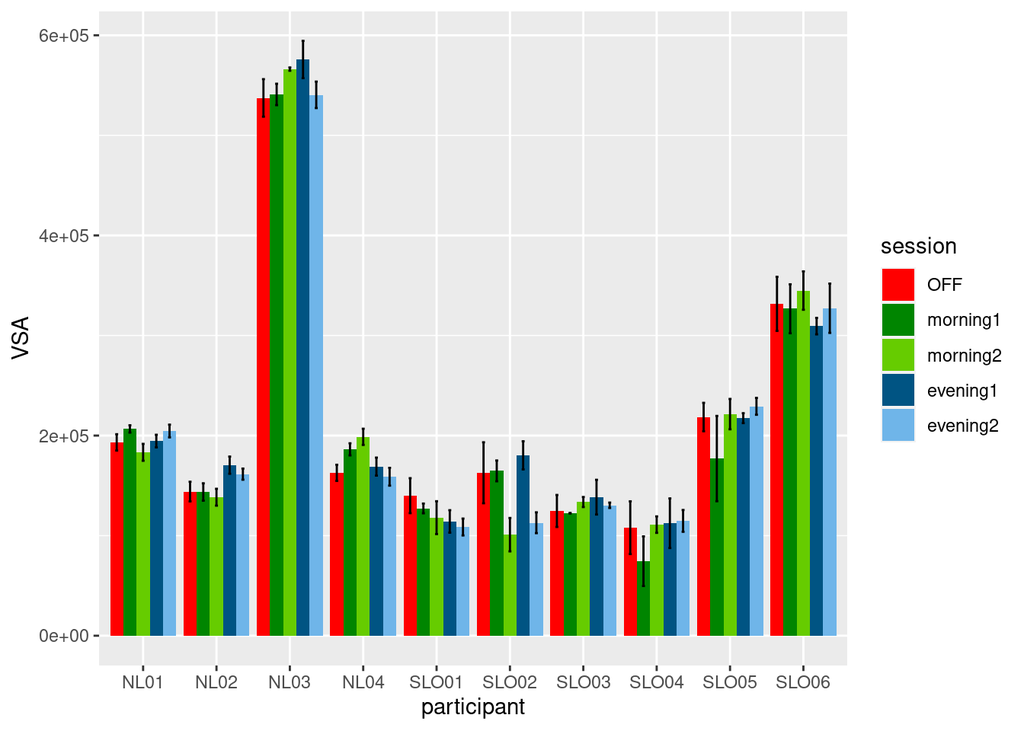

```r
ggplot(data=data[data$group=="PD",], aes(x=participant.id, y=VSA, fill=session)) +
  geom_bar(stat="summary", fun.y=mean, position='dodge') +
   stat_summary(fun.data = "mean_se", geom = 'errorbar', position=position_dodge(.9), width = 0.2) + scale_fill_manual(values = c("#ff0000","#008500", "#66cc00","#005483","#6fb5e9")) + labs(x = "participant")
```

```
## No summary function supplied, defaulting to `mean_se()`
```

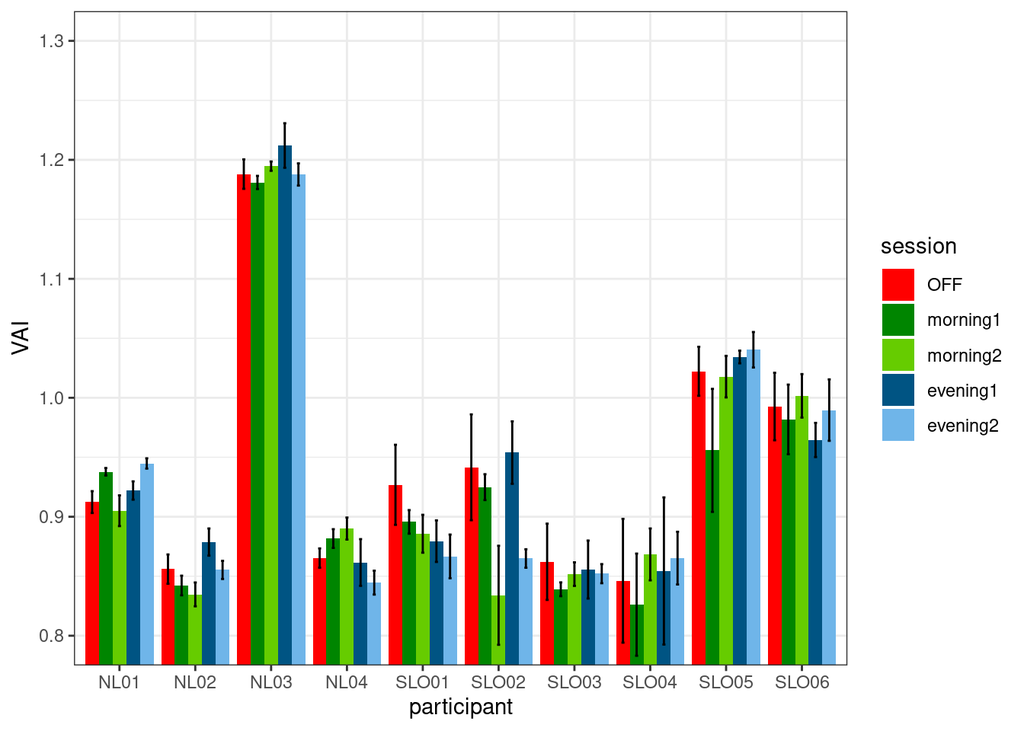

```r
ggplot(data=data[data$group=="PD",], aes(x=participant.id, y=VAI, fill=session)) +
  geom_bar(stat="summary", fun.y=mean, position='dodge') +
   stat_summary(fun.data = "mean_se", geom = 'errorbar', position=position_dodge(.9), width = 0.2) + scale_fill_manual(values = c("#ff0000","#008500", "#66cc00","#005483","#6fb5e9")) + coord_cartesian(ylim = c(0.8, 1.3)) + labs(x = "participant") + theme_bw()
```

```
## No summary function supplied, defaulting to `mean_se()`
```

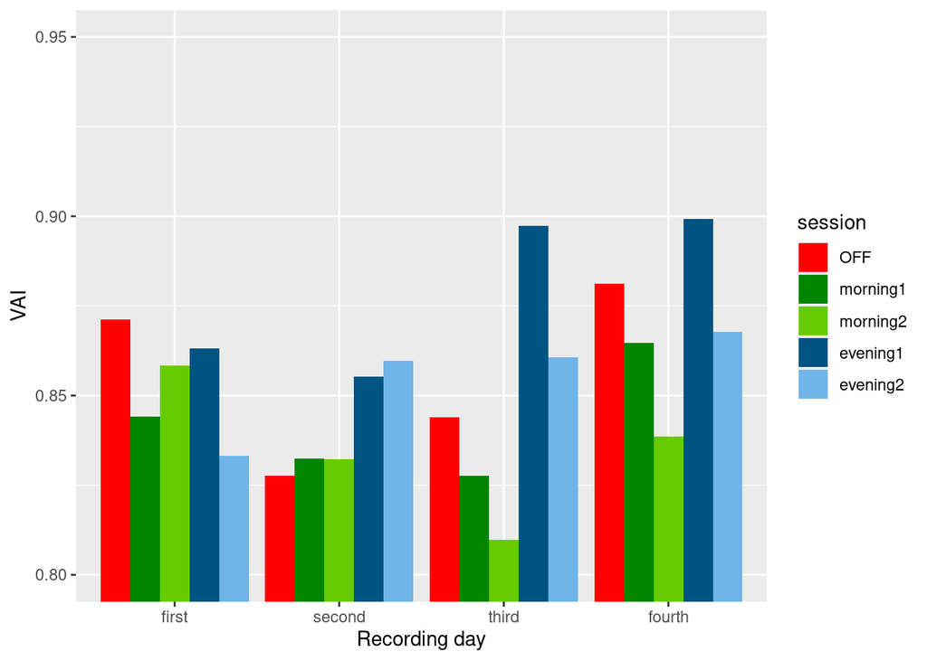

```r
#example of individual variation
ggplot(data=data[data$participant.id=="NL02",], aes(x=day, y=VAI, fill=session)) +
  geom_bar(stat="summary", fun.y=mean, position='dodge') +
   stat_summary(fun.data = "mean_se", geom = 'errorbar', position=position_dodge(.9), width = 0.2) + scale_fill_manual(values = c("#ff0000","#008500", "#66cc00","#005483","#6fb5e9")) + coord_cartesian(ylim = c(0.8, 0.95)) + labs(x = "Recording day")
```

```
## No summary function supplied, defaulting to `mean_se()`
```

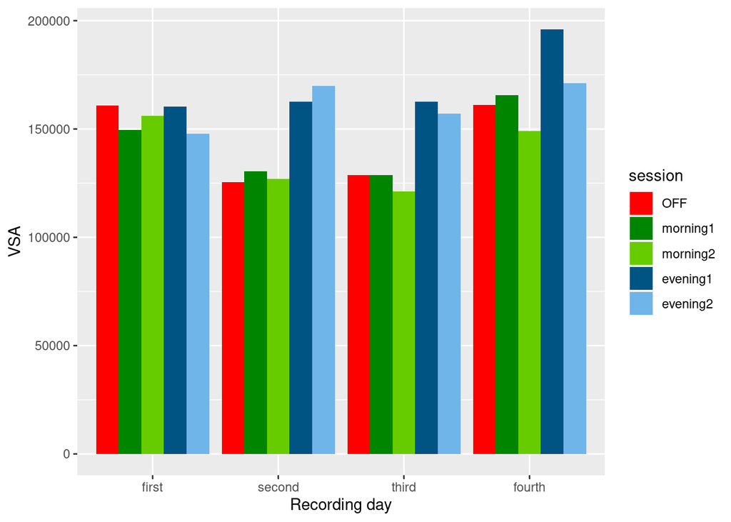

```r
#example of individual variation
ggplot(data=data[data$participant.id=="NL02",], aes(x=day, y=VSA, fill=session)) +
  geom_bar(stat="summary", fun.y=mean, position='dodge') +
   stat_summary(fun.data = "mean_se", geom = 'errorbar', position=position_dodge(.9), width = 0.2) + scale_fill_manual(values = c("#ff0000","#008500", "#66cc00","#005483","#6fb5e9")) + labs(x = "Recording day", y = "VSA")
```

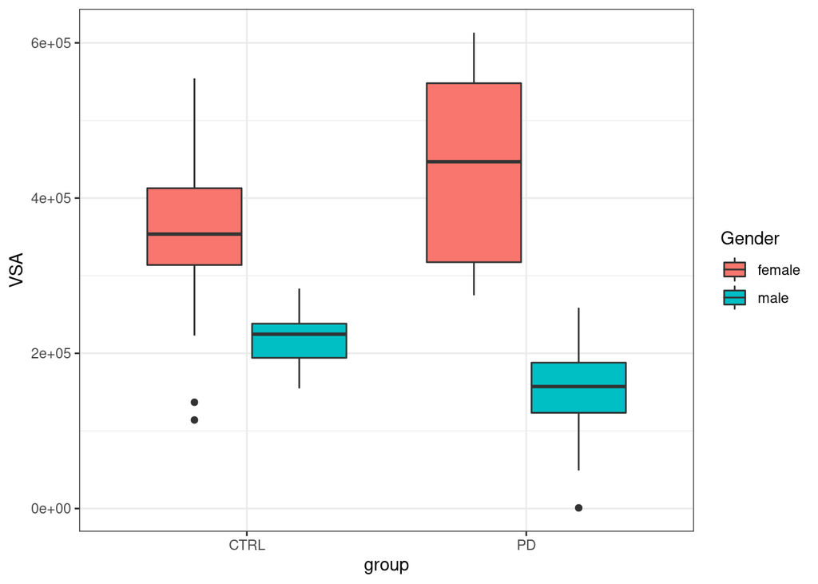

```r
ggplot(data, aes(x=group, y=VSA, fill=Gender)) + geom_boxplot() + labs(y = "VSA")  +
  theme_bw()
```

```
## No summary function supplied, defaulting to `mean_se()`
```

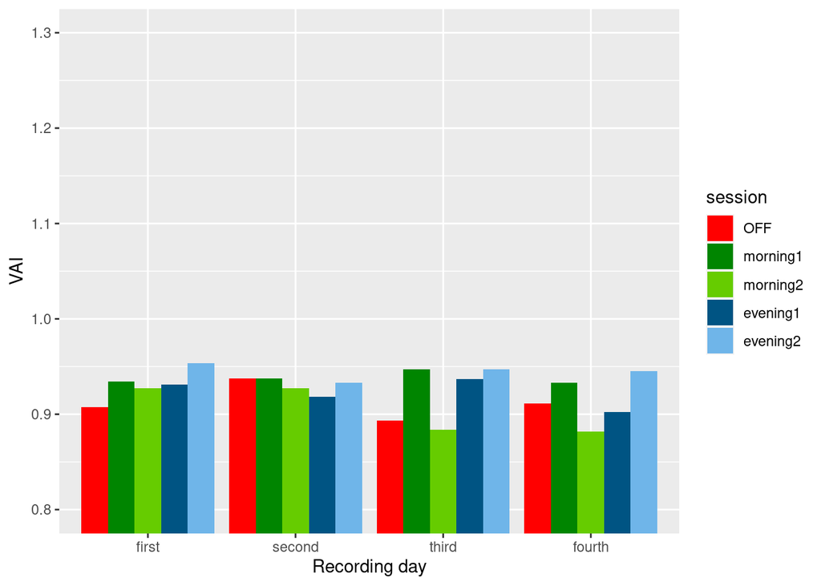

```r
### per participant ###
par(mfrow=c(4,2))

#example of individual variation
ggplot(data=data[data$participant.id=="NL01",], aes(x=day, y=VAI, fill=session)) +
  geom_bar(stat="summary", fun.y=mean, position='dodge') +
   stat_summary(fun.data = "mean_se", geom = 'errorbar', position=position_dodge(.9), width = 0.2) + scale_fill_manual(values = c("#ff0000","#008500", "#66cc00","#005483","#6fb5e9")) + coord_cartesian(ylim = c(0.8, 1.3)) + labs(x = "Recording day")
```

```
## No summary function supplied, defaulting to `mean_se()`
```

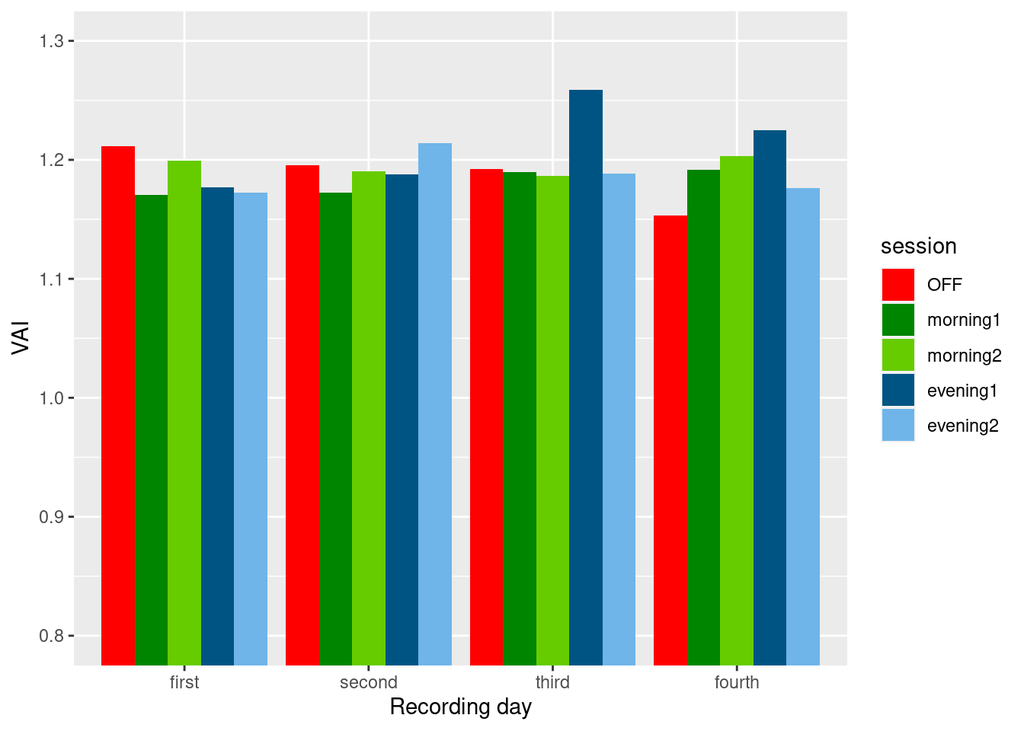

```r
#example of individual variation
ggplot(data=data[data$participant.id=="NL03",], aes(x=day, y=VAI, fill=session)) +
  geom_bar(stat="summary", fun.y=mean, position='dodge') +
   stat_summary(fun.data = "mean_se", geom = 'errorbar', position=position_dodge(.9), width = 0.2) + scale_fill_manual(values = c("#ff0000","#008500", "#66cc00","#005483","#6fb5e9")) + coord_cartesian(ylim = c(0.8, 1.3)) + labs(x = "Recording day")
```

```
## No summary function supplied, defaulting to `mean_se()`
```

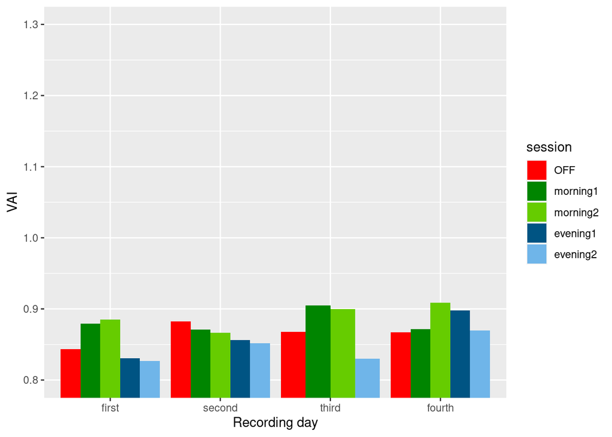

```r
#example of individual variation
ggplot(data=data[data$participant.id=="NL04",], aes(x=day, y=VAI, fill=session)) +
  geom_bar(stat="summary", fun.y=mean, position='dodge') +
   stat_summary(fun.data = "mean_se", geom = 'errorbar', position=position_dodge(.9), width = 0.2) + scale_fill_manual(values = c("#ff0000","#008500", "#66cc00","#005483","#6fb5e9")) + coord_cartesian(ylim = c(0.8, 1.3)) + labs(x = "Recording day")
```

```
## No summary function supplied, defaulting to `mean_se()`
```

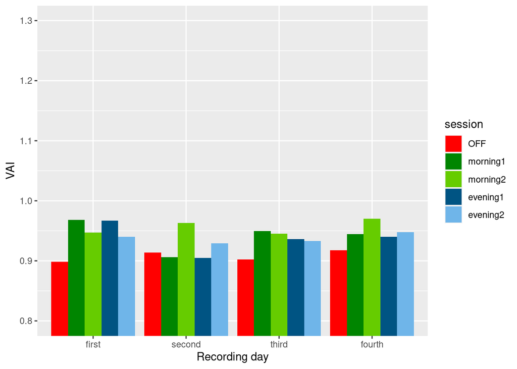

```r
#example of individual variation
ggplot(data=data[data$participant.id=="NL05",], aes(x=day, y=VAI, fill=session)) +
  geom_bar(stat="summary", fun.y=mean, position='dodge') +
   stat_summary(fun.data = "mean_se", geom = 'errorbar', position=position_dodge(.9), width = 0.2) + scale_fill_manual(values = c("#ff0000","#008500", "#66cc00","#005483","#6fb5e9")) + coord_cartesian(ylim = c(0.8, 1.3)) + labs(x = "Recording day")
```

```
## No summary function supplied, defaulting to `mean_se()`
```

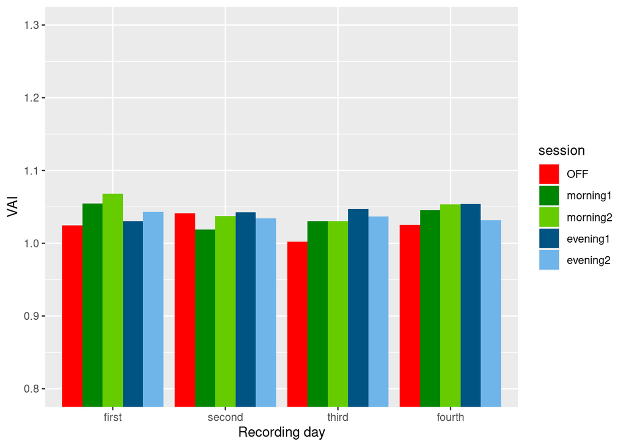

```r
#example of individual variation
ggplot(data=data[data$participant.id=="NL06",], aes(x=day, y=VAI, fill=session)) +
  geom_bar(stat="summary", fun.y=mean, position='dodge') +
   stat_summary(fun.data = "mean_se", geom = 'errorbar', position=position_dodge(.9), width = 0.2) + scale_fill_manual(values = c("#ff0000","#008500", "#66cc00","#005483","#6fb5e9")) + coord_cartesian(ylim = c(0.8, 1.3)) + labs(x = "Recording day")
```

```
## No summary function supplied, defaulting to `mean_se()`
```

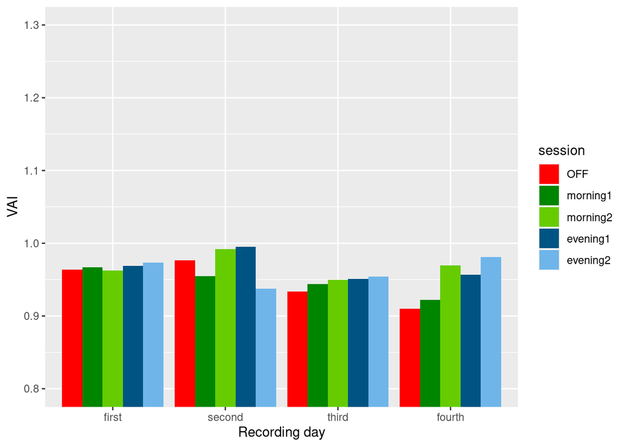

```r
#example of individual variation
ggplot(data=data[data$participant.id=="NL07",], aes(x=day, y=VAI, fill=session)) +
  geom_bar(stat="summary", fun.y=mean, position='dodge') +
   stat_summary(fun.data = "mean_se", geom = 'errorbar', position=position_dodge(.9), width = 0.2) + scale_fill_manual(values = c("#ff0000","#008500", "#66cc00","#005483","#6fb5e9")) + coord_cartesian(ylim = c(0.8, 1.3)) + labs(x = "Recording day")
```

Figures to report:

```
## No summary function supplied, defaulting to `mean_se()`
```

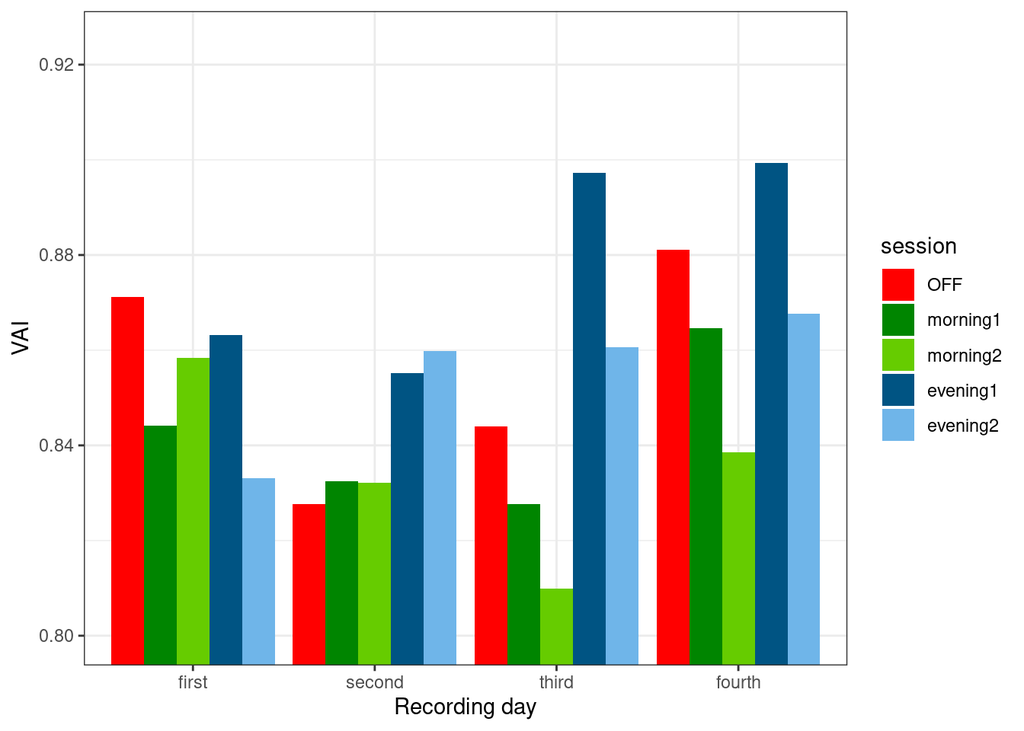

```r
#example of individual variation
ggplot(data=data[data$participant.id=="NL02",], aes(x=day, y=VAI, fill=session)) +
  geom_bar(stat="summary", fun.y=mean, position='dodge') +
   stat_summary(fun.data = "mean_se", geom = 'errorbar', position=position_dodge(.9), width = 0.2) + scale_fill_manual(values = c("#ff0000","#008500", "#66cc00","#005483","#6fb5e9")) + coord_cartesian(ylim = c(0.8, 0.925)) + labs(x = "Recording day") + theme_bw()
```

```
## No summary function supplied, defaulting to `mean_se()`
```

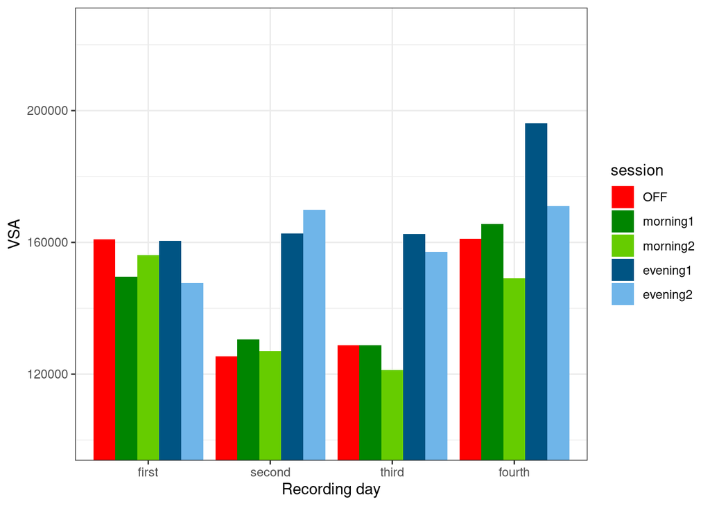

```r
#example of individual variation
ggplot(data=data[data$participant.id=="NL02",], aes(x=day, y=VSA, fill=session)) +
  geom_bar(stat="summary", fun.y=mean, position='dodge') +
   stat_summary(fun.data = "mean_se", geom = 'errorbar', position=position_dodge(.9), width = 0.2) + scale_fill_manual(values = c("#ff0000","#008500", "#66cc00","#005483","#6fb5e9")) + coord_cartesian(ylim = c(100000, 225000)) + labs(x = "Recording day") + theme_bw()
```